# Simulazione elezioni politiche

Author

Luca Fornasari

Published

September 10, 2022

Questo report contiene i risultati di una simulazione delle prossime elezioni della Camera dei Deputati e del Senato della Repubblica Italiana, ottenuti partendo da un sondaggio politico e dai risultati delle precedenti elezioni. Da questi vengono simulati i possibili voti presi da ciascuna lista in ciascun collegio, e dai voti vengono poi calcolati il numero di eletti per ciascuna lista.

Avverto che ho fatto questa simulazione per curiosità e non per lavoro, e che potrebbero essermi sfuggiti degli errori nel processo di simulazione, i risultati vanno dunque presi senza alcuna garanzia di accuratezza.

Segnalazioni, richieste e suggerimenti a fornaeffe@gmail.com o sul repository https://github.com/fornaeffe/elezioni.

## Dati di input

Sono stati considerati i seguenti sondaggi:

| Lista | cise | lab2101 | BiDiMedia | IPSOS | Noto | BiDiMedia - Fanpage | Coal. | Area |
| --- | --- | --- | --- | --- | --- | --- | --- | --- |
| FdI | 23.0% | 22.8% | 24.7% | 25.1% | 24.3% | 25.3% | DX | DX |
| PD | 21.4% | 25.3% | 23.7% | 20.5% | 19.5% | 23.3% | CSX | CENTRO |
| M5S | 16.6% | 11.1% | 11.6% | 14.5% | 13.5% | 12.0% |  | M5S |
| Lega | 9.6% | 16.7% | 12.5% | 12.5% | 13.0% | 12.3% | DX | DX |
| FI | 8.0% | 5.9% | 6.7% | 8.0% | 6.9% | 6.7% | DX | DX |
| Azione-IV | 5.3% | 6.6% | 6.6% | 6.7% | 7.7% | 6.4% |  | CENTRO |
| Verdi Sinistra | 5.9% | 3.1% | 4.1% | 3.4% | 2.7% | 4.1% | CSX | SX-VERDI |
| Italexit | 3.6% |  | 2.4% | 3.0% | 2.7% | 2.5% |  | DX |
| +EUROPA | 2.3% | 1.7% | 1.6% | 2.5% | 1.3% | 1.7% | CSX | CENTRO |
| Noi Moderati | 0.9% | 2.7% | 1.5% | 1.0% | 2.5% | 1.5% | DX | DX |
| UP |  |  | 1.5% | 1.0% |  | 1.3% |  | SX-VERDI |
| IC | 1.4% | 1.3% | 0.7% | 0.8% | 2.2% | 0.7% | CSX | M5S |
| ISP |  |  | 0.8% |  |  |  |  | ALTRI |
| Vita |  |  | 0.5% |  |  |  |  | ALTRI |
| altri | 2.0% | 2.8% | 1.1% | 1.0% |  | 2.2% |  |  |
| astenuti | 33.7% |  | 34.0% | 33.4% |  | 34.0% |  |  |

## Dettagli del procedimento

I collegi uninominali e plurinominali, e il rispettivo numero di seggi, sono stati ricavati dai Decreti del Presidente della Repubblica del 21 luglio 2022.

I candidati sono stati ricavati da [Eligendo](https://dait.interno.gov.it/elezioni/trasparenza/elezioni-politiche-2022).

I voti di ogni lista in ciascun collegio uninominale sono stati stimati in questo modo:

1. Sono stati recuperati i dati delle elezioni della Camera del 2018, delle elezioni europee del 2019 e delle elezioni regionali dal 2018 ad oggi.
2. Le liste (sia delle passate elezioni sia della futura elezione) sono state raggruppate in “aree politiche” (vedi tabella sopra), aggiungendo una ulteriore area “astensione”.
3. Basandosi sui risultati delle elezioni precedenti, per ciascuna provincia è stata stimata la percentuale di popolazione “appartenente” a ciascuna area politica.
4. Per ciascuna area politica è stata calcolata quindi la percentuale di popolazione di quella area politica presente nella provincia, rispetto al totale nazionale, cioè è stata calcolata la distribuzione geografica di ogni area politica.
5. Sono state effettuate 1000 simulazioni. In ciascuna di esse:
   1. La percentuale nazionale di ciascuna lista è stata estratta a sorte da una distribuzione che ha una media e una deviazione standard ricavate dai sondaggi considerati.
   2. Per ciascuna area politica, i voti nazionali (calcolati in base alle percentuali dei sondaggi mostrate nella tabella sopra) sono stati divisi nelle diverse provincie in base alla distribuzione calcolata al punto 4.
   3. Sono state calcolate le percentuali di ogni area all’interno di ogni provincia, rispetto al totale di voti assegnati a ogni provincia.
   4. A partire dalle percentuali del punto 6 sono state calcolate le percentuali di ogni area all’interno di ogni collegio uninominale di Camera e Senato, in base a quali comuni di quali provincie appartengono a ciascun collegio.
   5. In ogni collegio, le percentuali di ciascuna area sono state suddivise tra le liste di quell’area proporzionalmente alla percentuale nazionale (da sondaggio) di ciascuna lista.
   6. La percentuale di ciascuna lista in ciascun collegio è stata fatta variare leggermente rispetto a quella calcolata al punto precedente, la variabilità di questa percentuale è stata ricavata dalle precedenti elezioni.

Se qualcuno ha a disposizione stime più precise delle percentuali su base locale, le integro volentieri della simulazione.

Una volta ottenuti i voti per ciascun collegio, sono stati applicati alla lettera il DPR 361/57 e il D.Lgs. 533/93 (con l’unica eccezione dei casi di parità da risolvere con sorteggio, e per il Senato applicando, in caso di incapienza di una lista, quanto accaduto a seguito delle elezioni 2018, cioè andando a ripescare candidati non eletti anche da altre regioni).

**Non sono stati simulati i seggi delle circoscrizioni Estero e Valle d’Aosta.**

**Sto trascurando SVP, dunque i risultati, soprattutto per il Trentino-Alto Adige, potrebbero essere falsati**

Gli script per l’esecuzione dell’analisi si trovano in questo repository: https://github.com/fornaeffe/elezioni

L’analisi è stata svolta con R version 4.2.1 (2022-06-23 ucrt).

## Risultati

Nei grafici seguenti è mostrata la composizione mediana dei due rami del Parlamento.

I seggi attribuiti attraverso il sistema maggioritario nei collegi **uninominali** sono indicati con **“Magg.”** seguito dal nome della **coalizione**.

I seggi attribuiti attraverso il sistema proporzionale nei collegi **plurinominali** sono indicati con **“Prop.”** seguito dal nome della **lista**.

Nota: poiché per ogni coalizione o lista è stato preso il valore mediano tra tutte le simulazioni, e i valori di ciascuna coalizione o lista potrebbero non provenire dalla stessa simulazione, il totale dei seggi potrebbe essere leggermente differente da 400 (nel caso della Camera) o 200 (nel caso del Senato).

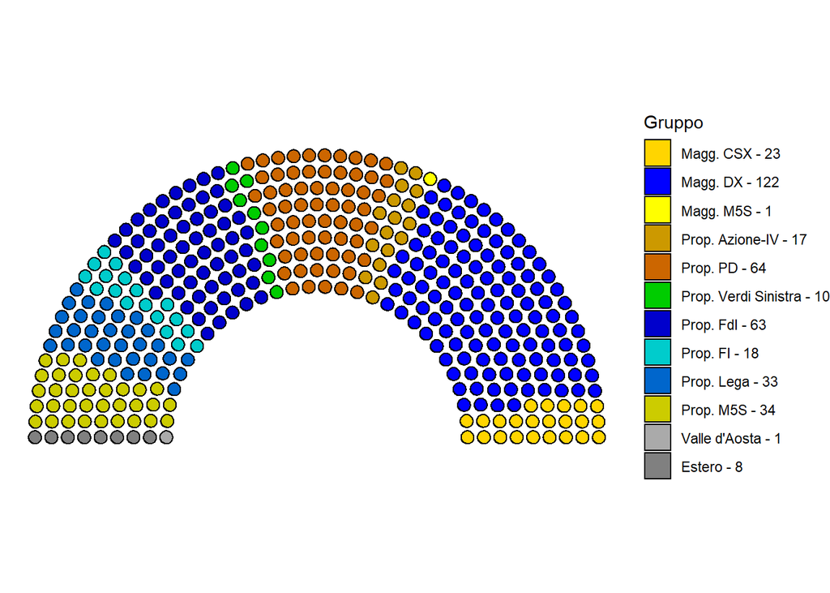

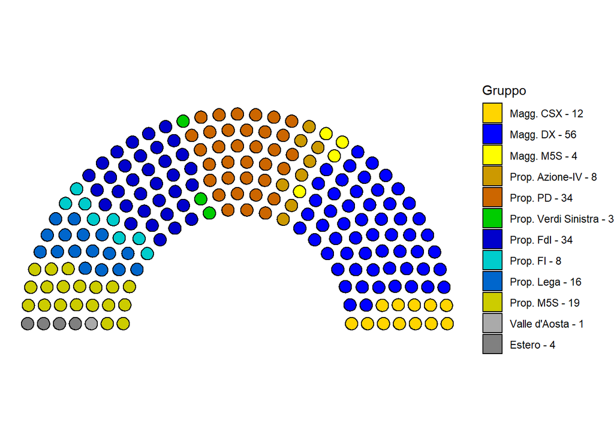

### Probabilità di superare la soglia

camera

| LISTA | Prob. di eleggere da coll. plurin. |
| --- | --- |
| +EUROPA | 1% |
| Azione-IV | 100% |
| FdI | 100% |
| FI | 100% |
| IC | 1% |
| Italexit | 30% |
| Lega | 100% |
| M5S | 100% |
| Noi Moderati | 6% |
| PD | 100% |
| UP | 0% |
| Verdi Sinistra | 79% |

senato

| LISTA | Prob. di eleggere da coll. plurin. |
| --- | --- |
| +EUROPA | 2% |
| Azione-IV | 100% |
| FdI | 100% |
| FI | 100% |
| IC | 1% |
| Italexit | 31% |
| Lega | 100% |
| M5S | 100% |
| Noi Moderati | 6% |
| PD | 100% |
| UP | 0% |
| Verdi Sinistra | 76% |

### Eletti rispetto alla percentuale

Nei grafici seguenti è mostrato il numero di eletti (rispettivamente totali, nei collegi uninominali e nei collegi plurinominali) per ciascuna coalizione o ciascuna lista, a seconda della percentuale di voti ottenuta dalla coalizione o lista. Ogni punto rappresenta una diversa simulazione, i punti relativi a una coalizione o una lista formano una “nuvola” perché in ciascuna simulazione la percentuale è libera di variare leggermente rispetto alla percentuale stimata dai sondaggi, e di conseguenza la coalizione o la lista ottiene un numero più o meno alto di seggi.

La linea orizzontale punteggiata rappresenta la metà dei seggi (esclusi quelli di Val d’Aosta ed Estero, che non sono stati simulati).

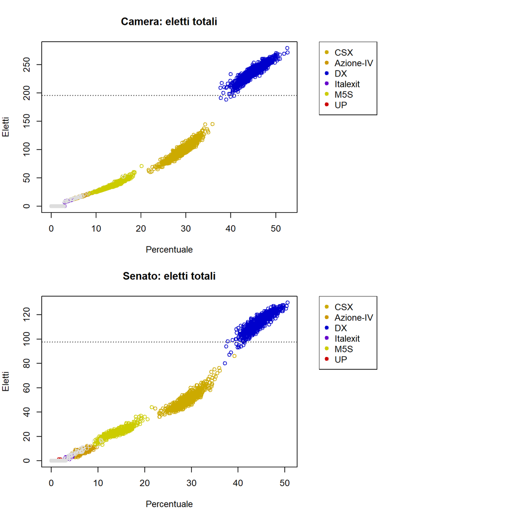

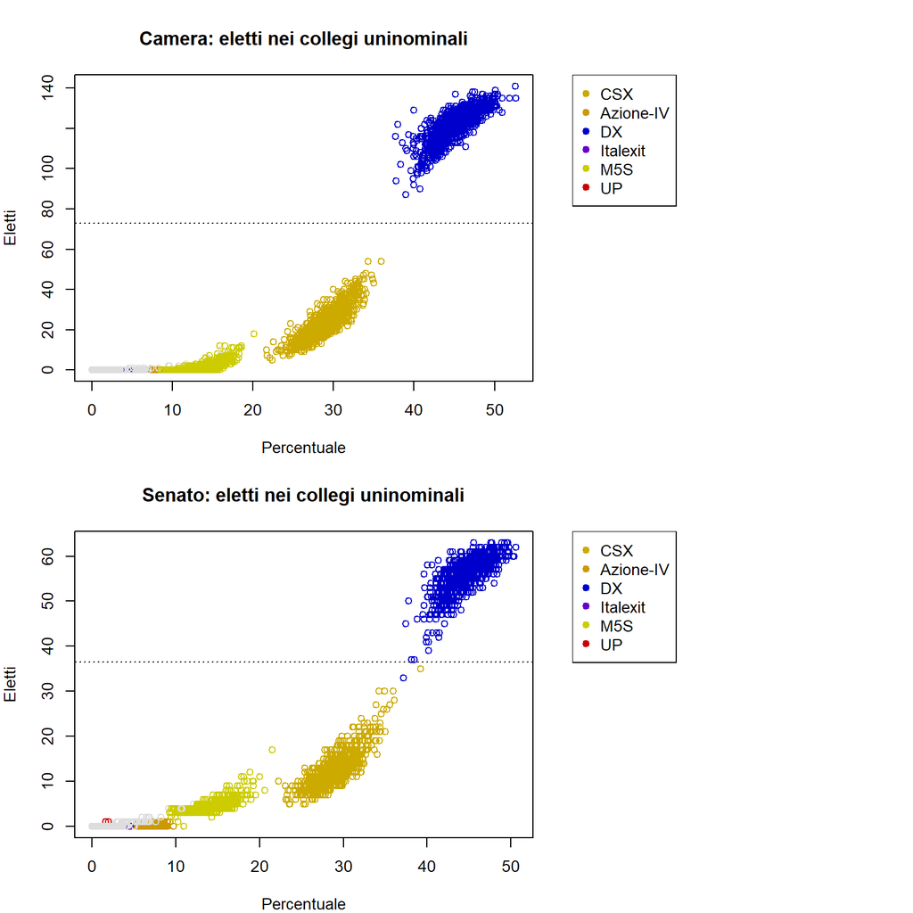

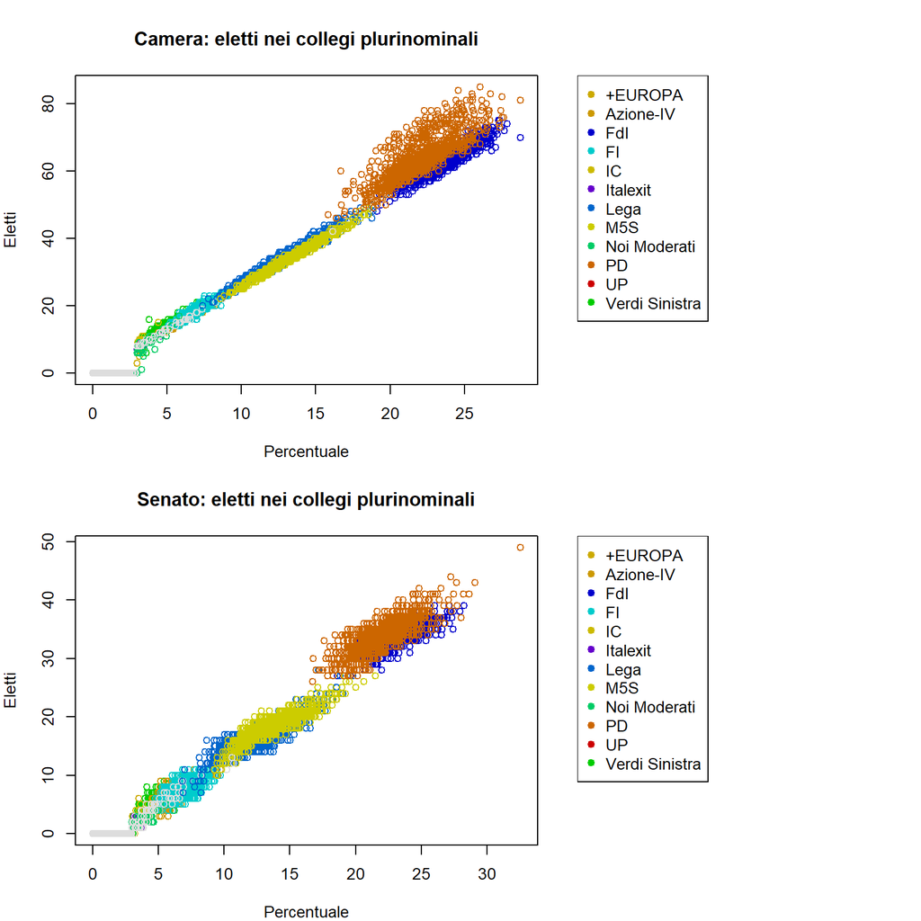

### Probabilità di vittoria in ciascun collegio uninominale della **Camera**

Nella tabella seguente, per ciascun collegio uninominale, è mostrata la probabilità di vittoria di ciascuna coalizione.

| COLLEGIOUNINOMINALE | Azione-IV | CSX | DX | Italexit | M5S | UP |
| --- | --- | --- | --- | --- | --- | --- |
| ABRUZZO - U01 | 0 | 0.004 | 0.994 | 0 | 0.002 | 0 |
| ABRUZZO - U02 | 0 | 0.002 | 0.998 | 0 | 0.000 | 0 |
| ABRUZZO - U03 | 0 | 0.000 | 1.000 | 0 | 0.000 | 0 |
| BASILICATA - U01 | 0 | 0.122 | 0.875 | 0 | 0.003 | 0 |
| CALABRIA - U01 | 0 | 0.005 | 0.995 | 0 | 0.000 | 0 |
| CALABRIA - U02 | 0 | 0.003 | 0.997 | 0 | 0.000 | 0 |
| CALABRIA - U03 | 0 | 0.003 | 0.997 | 0 | 0.000 | 0 |
| CALABRIA - U04 | 0 | 0.000 | 0.999 | 0 | 0.000 | 0 |
| CALABRIA - U05 | 0 | 0.000 | 1.000 | 0 | 0.000 | 0 |
| CAMPANIA 1 - U01 | 0 | 0.934 | 0.036 | 0 | 0.030 | 0 |
| CAMPANIA 1 - U02 | 0 | 0.959 | 0.027 | 0 | 0.014 | 0 |
| CAMPANIA 1 - U03 | 0 | 0.952 | 0.032 | 0 | 0.016 | 0 |
| CAMPANIA 1 - U04 | 0 | 0.942 | 0.036 | 0 | 0.022 | 0 |
| CAMPANIA 1 - U05 | 0 | 0.942 | 0.039 | 0 | 0.019 | 0 |
| CAMPANIA 1 - U06 | 0 | 0.926 | 0.042 | 0 | 0.032 | 0 |
| CAMPANIA 1 - U07 | 0 | 0.937 | 0.038 | 0 | 0.025 | 0 |
| CAMPANIA 2 - U01 | 0 | 0.523 | 0.471 | 0 | 0.004 | 0 |
| CAMPANIA 2 - U02 | 0 | 0.507 | 0.485 | 0 | 0.008 | 0 |
| CAMPANIA 2 - U03 | 0 | 0.439 | 0.561 | 0 | 0.000 | 0 |
| CAMPANIA 2 - U04 | 0 | 0.875 | 0.122 | 0 | 0.001 | 0 |
| CAMPANIA 2 - U05 | 0 | 0.768 | 0.232 | 0 | 0.000 | 0 |
| CAMPANIA 2 - U06 | 0 | 0.760 | 0.240 | 0 | 0.000 | 0 |
| CAMPANIA 2 - U07 | 0 | 0.761 | 0.238 | 0 | 0.000 | 0 |
| EMILIA-ROMAGNA - U01 | 0 | 0.002 | 0.998 | 0 | 0.000 | 0 |
| EMILIA-ROMAGNA - U02 | 0 | 0.063 | 0.937 | 0 | 0.000 | 0 |
| EMILIA-ROMAGNA - U03 | 0 | 0.740 | 0.260 | 0 | 0.000 | 0 |
| EMILIA-ROMAGNA - U04 | 0 | 0.485 | 0.515 | 0 | 0.000 | 0 |
| EMILIA-ROMAGNA - U05 | 0 | 0.865 | 0.135 | 0 | 0.000 | 0 |
| EMILIA-ROMAGNA - U06 | 0 | 0.891 | 0.109 | 0 | 0.000 | 0 |
| EMILIA-ROMAGNA - U07 | 0 | 0.778 | 0.222 | 0 | 0.000 | 0 |

[output cut: 116 more lines]

### Probabilità di vittoria in ciascun collegio uninominale del **Senato**

Nella tabella seguente, per ciascun collegio uninominale, è mostrata la probabilità di vittoria di ciascuna coalizione.

| COLLEGIOUNINOMINALE | Azione-IV | CSX | DX | Italexit | M5S | UP |
| --- | --- | --- | --- | --- | --- | --- |
| ABRUZZO - U01 | 0.000 | 0.0040 | 0.996 | 0 | 0.000 | 0.000 |
| BASILICATA - U01 | 0.000 | 0.1320 | 0.864 | 0 | 0.004 | 0.000 |
| CALABRIA - U01 | 0.000 | 0.0050 | 0.995 | 0 | 0.000 | 0.000 |
| CALABRIA - U02 | 0.000 | 0.0000 | 1.000 | 0 | 0.000 | 0.000 |
| CAMPANIA - U01 | 0.000 | 0.5050 | 0.487 | 0 | 0.008 | 0.000 |
| CAMPANIA - U02 | 0.000 | 0.7360 | 0.263 | 0 | 0.001 | 0.000 |
| CAMPANIA - U03 | 0.000 | 0.7650 | 0.234 | 0 | 0.001 | 0.000 |
| CAMPANIA - U04 | 0.000 | 0.9190 | 0.041 | 0 | 0.040 | 0.000 |
| CAMPANIA - U05 | 0.000 | 0.9480 | 0.029 | 0 | 0.023 | 0.000 |
| CAMPANIA - U06 | 0.000 | 0.9360 | 0.056 | 0 | 0.008 | 0.000 |
| CAMPANIA - U07 | 0.000 | 0.9280 | 0.051 | 0 | 0.021 | 0.000 |
| EMILIA-ROMAGNA - U01 | 0.000 | 0.0250 | 0.975 | 0 | 0.000 | 0.000 |
| EMILIA-ROMAGNA - U02 | 0.000 | 0.5960 | 0.404 | 0 | 0.000 | 0.000 |
| EMILIA-ROMAGNA - U03 | 0.000 | 0.8410 | 0.159 | 0 | 0.000 | 0.000 |
| EMILIA-ROMAGNA - U04 | 0.000 | 0.1540 | 0.846 | 0 | 0.000 | 0.000 |
| EMILIA-ROMAGNA - U05 | 0.000 | 0.1910 | 0.809 | 0 | 0.000 | 0.000 |
| FRIULI-VENEZIA GIULIA - U01 | 0.000 | 0.0010 | 0.997 | 0 | 0.000 | 0.000 |
| LAZIO - U01 | 0.000 | 0.0060 | 0.994 | 0 | 0.000 | 0.000 |
| LAZIO - U02 | 0.000 | 0.1160 | 0.884 | 0 | 0.000 | 0.000 |
| LAZIO - U03 | 0.000 | 0.1250 | 0.875 | 0 | 0.000 | 0.000 |
| LAZIO - U04 | 0.000 | 0.1090 | 0.891 | 0 | 0.000 | 0.000 |
| LAZIO - U05 | 0.000 | 0.0950 | 0.905 | 0 | 0.000 | 0.000 |
| LAZIO - U06 | 0.000 | 0.0000 | 1.000 | 0 | 0.000 | 0.000 |
| LIGURIA - U01 | 0.000 | 0.0050 | 0.995 | 0 | 0.000 | 0.000 |
| LIGURIA - U02 | 0.000 | 0.0610 | 0.939 | 0 | 0.000 | 0.000 |
| LOMBARDIA - U01 | 0.000 | 0.0000 | 1.000 | 0 | 0.000 | 0.000 |
| LOMBARDIA - U02 | 0.000 | 0.0000 | 1.000 | 0 | 0.000 | 0.000 |
| LOMBARDIA - U03 | 0.000 | 0.0920 | 0.908 | 0 | 0.000 | 0.000 |
| LOMBARDIA - U04 | 0.000 | 0.0750 | 0.925 | 0 | 0.000 | 0.000 |
| LOMBARDIA - U05 | 0.000 | 0.0750 | 0.925 | 0 | 0.000 | 0.000 |
| LOMBARDIA - U06 | 0.000 | 0.0010 | 0.999 | 0 | 0.000 | 0.000 |
| LOMBARDIA - U07 | 0.000 | 0.0000 | 1.000 | 0 | 0.000 | 0.000 |
| LOMBARDIA - U08 | 0.000 | 0.0010 | 0.999 | 0 | 0.000 | 0.000 |
| LOMBARDIA - U09 | 0.000 | 0.0000 | 1.000 | 0 | 0.000 | 0.000 |
| LOMBARDIA - U10 | 0.000 | 0.0000 | 1.000 | 0 | 0.000 | 0.000 |
| LOMBARDIA - U11 | 0.000 | 0.0000 | 1.000 | 0 | 0.000 | 0.000 |
| MARCHE - U01 | 0.000 | 0.0000 | 1.000 | 0 | 0.000 | 0.000 |
| MARCHE - U02 | 0.000 | 0.1090 | 0.891 | 0 | 0.000 | 0.000 |
| MOLISE - U01 | 0.000 | 0.0040 | 0.988 | 0 | 0.008 | 0.000 |
| PIEMONTE - U01 | 0.000 | 0.0990 | 0.901 | 0 | 0.000 | 0.000 |
| PIEMONTE - U02 | 0.000 | 0.0980 | 0.902 | 0 | 0.000 | 0.000 |
| PIEMONTE - U03 | 0.000 | 0.0000 | 1.000 | 0 | 0.000 | 0.000 |
| PIEMONTE - U04 | 0.000 | 0.0000 | 1.000 | 0 | 0.000 | 0.000 |
| PIEMONTE - U05 | 0.000 | 0.0030 | 0.997 | 0 | 0.000 | 0.000 |
| PUGLIA - U01 | 0.000 | 0.0020 | 0.986 | 0 | 0.012 | 0.000 |
| PUGLIA - U02 | 0.000 | 0.0150 | 0.961 | 0 | 0.024 | 0.000 |
| PUGLIA - U03 | 0.000 | 0.0530 | 0.916 | 0 | 0.031 | 0.000 |
| PUGLIA - U04 | 0.000 | 0.0010 | 0.988 | 0 | 0.011 | 0.000 |
| PUGLIA - U05 | 0.000 | 0.0340 | 0.966 | 0 | 0.000 | 0.000 |
| SARDEGNA - U01 | 0.000 | 0.0400 | 0.957 | 0 | 0.001 | 0.000 |
| SARDEGNA - U02 | 0.000 | 0.0470 | 0.922 | 0 | 0.024 | 0.000 |
| SICILIA - U01 | 0.000 | 0.0010 | 0.983 | 0 | 0.016 | 0.000 |
| SICILIA - U02 | 0.000 | 0.0040 | 0.910 | 0 | 0.086 | 0.000 |
| SICILIA - U03 | 0.000 | 0.0000 | 0.984 | 0 | 0.016 | 0.000 |
| SICILIA - U04 | 0.000 | 0.0000 | 0.954 | 0 | 0.046 | 0.000 |
| SICILIA - U05 | 0.000 | 0.0020 | 0.865 | 0 | 0.133 | 0.000 |
| SICILIA - U06 | 0.000 | 0.0000 | 0.993 | 0 | 0.007 | 0.000 |
| TOSCANA - U01 | 0.000 | 0.2410 | 0.759 | 0 | 0.000 | 0.000 |
| TOSCANA - U02 | 0.000 | 0.3660 | 0.634 | 0 | 0.000 | 0.000 |
| TOSCANA - U03 | 0.000 | 0.0670 | 0.933 | 0 | 0.000 | 0.000 |
| TOSCANA - U04 | 0.000 | 0.9810 | 0.019 | 0 | 0.000 | 0.000 |
| TRENTINO-ALTO ADIGE/SÜDTIROL - U04 | 0.135 | 0.0000 | 0.000 | 0 | 0.814 | 0.002 |
| TRENTINO-ALTO ADIGE/SÜDTIROL - U05 | 0.000 | 0.4980 | 0.000 | 0 | 0.003 | 0.000 |
| TRENTINO-ALTO ADIGE/SÜDTIROL - U06 | 0.000 | 0.4965 | 0.000 | 0 | 0.004 | 0.000 |
| UMBRIA - U01 | 0.000 | 0.0100 | 0.990 | 0 | 0.000 | 0.000 |
| VENETO - U01 | 0.000 | 0.0000 | 1.000 | 0 | 0.000 | 0.000 |
| VENETO - U02 | 0.000 | 0.0000 | 1.000 | 0 | 0.000 | 0.000 |
| VENETO - U03 | 0.000 | 0.0000 | 1.000 | 0 | 0.000 | 0.000 |
| VENETO - U04 | 0.000 | 0.0000 | 1.000 | 0 | 0.000 | 0.000 |
| VENETO - U05 | 0.000 | 0.0000 | 1.000 | 0 | 0.000 | 0.000 |
| TRENTINO-ALTO ADIGE/SÜDTIROL - U01 | 0.000 | 0.0000 | 0.000 | 0 | 0.999 | 0.000 |
| TRENTINO-ALTO ADIGE/SÜDTIROL - U02 | 0.000 | 0.0000 | 0.000 | 0 | 0.995 | 0.000 |
| TRENTINO-ALTO ADIGE/SÜDTIROL - U03 | 0.000 | 0.0000 | 0.000 | 0 | 0.996 | 0.000 |

### Probabilità di elezione per ciascuna posizione nei collegi plurinominali

Nelle tabelle seguenti, per ciascuna lista e per ciascun ramo del Parlamento, è indicata la probabilità di elezione per il candidato in prima, seconda, terza e quarta posizione.

+EUROPA - camera

|  | 1 | 2 | 3 | 4 |
| --- | --- | --- | --- | --- |
| ABRUZZO - P01 | 0.2% | 0.0% | 0.0% | 0.0% |
| BASILICATA - P01 | 0.0% | 0.0% | 0.0% | 0.0% |
| CALABRIA - P01 | 0.0% | 0.0% | 0.0% | 0.0% |
| CAMPANIA 1 - P01 | 0.0% | 0.0% | 0.0% | 0.0% |
| CAMPANIA 1 - P02 | 0.9% | 0.0% | 0.0% | 0.0% |
| CAMPANIA 2 - P01 | 0.1% | 0.0% | 0.0% | 0.0% |
| CAMPANIA 2 - P02 | 1.0% | 0.0% | 0.0% | 0.0% |
| EMILIA-ROMAGNA - P01 | 0.0% | 0.0% | 0.0% | 0.0% |
| EMILIA-ROMAGNA - P02 | 1.3% | 0.4% | 0.3% | 0.0% |
| EMILIA-ROMAGNA - P03 | 0.0% | 0.0% | 0.0% | 0.0% |
| FRIULI-VENEZIA GIULIA - P01 | 0.2% | 0.0% | 0.0% | 0.0% |
| LAZIO 1 - P01 | 0.4% | 0.2% | 0.1% | 0.0% |
| LAZIO 1 - P02 | 0.2% | 0.0% | 0.0% | 0.0% |
| LAZIO 1 - P03 | 0.3% | 0.0% | 0.0% | 0.0% |
| LAZIO 2 - P01 | 0.0% | 0.0% | 0.0% | 0.0% |
| LAZIO 2 - P02 | 0.1% | 0.0% | 0.0% | 0.0% |
| LIGURIA - P01 | 0.2% | 0.0% | 0.0% | 0.0% |
| LOMBARDIA 1 - P01 | 0.7% | 0.3% | 0.0% | 0.0% |
| LOMBARDIA 1 - P02 | 0.5% | 0.1% | 0.0% | 0.0% |
| LOMBARDIA 2 - P01 | 0.0% | 0.0% | 0.0% | 0.0% |
| LOMBARDIA 2 - P02 | 0.2% | 0.0% | 0.0% | 0.0% |
| LOMBARDIA 3 - P01 | 0.0% | 0.0% | 0.0% | 0.0% |
| LOMBARDIA 3 - P02 | 0.1% | 0.0% | 0.0% | 0.0% |
| LOMBARDIA 4 - P01 | 0.1% | 0.0% | 0.0% | 0.0% |
| MARCHE - P01 | 0.0% | 0.0% | 0.0% | 0.0% |
| MOLISE - P01 | 0.0% | 0.0% | 0.0% | 0.0% |
| PIEMONTE 1 - P01 | 0.2% | 0.0% | 0.0% | 0.0% |
| PIEMONTE 1 - P02 | 0.6% | 0.0% | 0.0% | 0.0% |
| PIEMONTE 2 - P01 | 0.0% | 0.0% | 0.0% | 0.0% |
| PIEMONTE 2 - P02 | 0.1% | 0.0% | 0.0% | 0.0% |
| PUGLIA - P01 | 0.0% | 0.0% | 0.0% | 0.0% |
| PUGLIA - P02 | 0.2% | 0.0% | 0.0% | 0.0% |
| PUGLIA - P03 | 0.0% | 0.0% | 0.0% | 0.0% |
| PUGLIA - P04 | 0.6% | 0.0% | 0.0% | 0.0% |
| SARDEGNA - P01 | 0.2% | 0.0% | 0.0% | 0.0% |
| SICILIA 1 - P01 | 0.1% | 0.1% | 0.0% | 0.0% |
| SICILIA 1 - P02 | 0.0% | 0.0% | 0.0% | 0.0% |
| SICILIA 2 - P01 | 0.0% | 0.0% | 0.0% | 0.0% |
| SICILIA 2 - P02 | 0.1% | 0.0% | 0.0% | 0.0% |
| SICILIA 2 - P03 | 0.1% | 0.0% | 0.0% | 0.0% |
| TOSCANA - P01 | 0.0% | 0.0% | 0.0% | 0.0% |
| TOSCANA - P02 | 0.3% | 0.0% | 0.0% | 0.0% |
| TOSCANA - P03 | 0.7% | 0.0% | 0.0% | 0.0% |
| TRENTINO-ALTO ADIGE/SÜDTIROL - P01 | 0.0% | 0.0% | 0.0% | 0.0% |
| UMBRIA - P01 | 0.0% | 0.0% | 0.0% | 0.0% |
| VENETO 1 - P01 | 0.1% | 0.0% | 0.0% | 0.0% |
| VENETO 2 - P01 | 0.2% | 0.0% | 0.0% | 0.0% |
| VENETO 2 - P02 | 0.1% | 0.0% | 0.0% | 0.0% |
| VENETO 2 - P03 | 0.2% | 0.0% | 0.0% | 0.0% |

+EUROPA - senato

|  | 1 | 2 | 3 | 4 |
| --- | --- | --- | --- | --- |
| ABRUZZO - P01 | 0.0% | 0.0% | 0.0% | 0.0% |
| BASILICATA - P01 | 0.0% | 0.0% | 0.0% | 0.0% |
| CALABRIA - P01 | 0.0% | 0.0% | 0.0% | 0.0% |
| CAMPANIA - P01 | 1.1% | 0.9% | 0.0% | 0.0% |
| CAMPANIA - P02 | 0.0% | 0.0% | 0.0% | 0.0% |
| EMILIA-ROMAGNA - P01 | 0.1% | 0.0% | 0.0% | 0.0% |
| EMILIA-ROMAGNA - P02 | 0.2% | 0.1% | 0.1% | 0.0% |
| FRIULI-VENEZIA GIULIA - P01 | 0.0% | 0.0% | 0.0% | 0.0% |
| LAZIO - P01 | 0.2% | 0.1% | 0.1% | 0.0% |
| LAZIO - P02 | 0.0% | 0.0% | 0.0% | 0.0% |
| LIGURIA - P01 | 0.0% | 0.0% | 0.0% | 0.0% |
| LOMBARDIA - P01 | 0.0% | 0.0% | 0.0% | 0.0% |
| LOMBARDIA - P02 | 1.2% | 0.6% | 0.0% | 0.0% |
| LOMBARDIA - P03 | 0.0% | 0.0% | 0.0% | 0.0% |
| MARCHE - P01 | 0.0% | 0.0% | 0.0% | 0.0% |
| MOLISE - P01 | 0.0% | 0.0% | 0.0% | 0.0% |
| PIEMONTE - P01 | 0.1% | 0.1% | 0.0% | 0.0% |
| PIEMONTE - P02 | 0.1% | 0.0% | 0.0% | 0.0% |
| PUGLIA - P01 | 0.0% | 0.0% | 0.0% | 0.0% |
| SARDEGNA - P01 | 0.0% | 0.0% | 0.0% | 0.0% |
| SICILIA - P01 | 0.0% | 0.0% | 0.0% | 0.0% |
| SICILIA - P02 | 0.0% | 0.0% | 0.0% | 0.0% |
| TOSCANA - P01 | 0.1% | 0.1% | 0.0% | 0.0% |
| UMBRIA - P01 | 0.0% | 0.0% | 0.0% | 0.0% |
| VENETO - P01 | 0.1% | 0.1% | 0.0% | 0.0% |
| VENETO - P02 | 0.0% | 0.0% | 0.0% | 0.0% |

AZIONE - ITALIA VIVA - CALENDA - camera

|  | 1 | 2 | 3 | 4 |
| --- | --- | --- | --- | --- |
| ABRUZZO - P01 | 15.6% | 0.0% | 0.0% | 0.0% |
| BASILICATA - P01 | 24.3% | 0.0% | 0.0% | 0.0% |
| CALABRIA - P01 | 72.2% | 0.2% | 0.0% | 0.0% |
| CAMPANIA 1 - P01 | 24.3% | 13.7% | 0.0% | 0.0% |
| CAMPANIA 1 - P02 | 87.5% | 36.3% | 0.0% | 0.0% |
| CAMPANIA 2 - P01 | 2.2% | 0.0% | 0.0% | 0.0% |
| CAMPANIA 2 - P02 | 98.8% | 98.6% | 0.0% | 0.0% |
| EMILIA-ROMAGNA - P01 | 9.1% | 2.0% | 0.0% | 0.0% |
| EMILIA-ROMAGNA - P02 | 99.3% | 58.6% | 0.0% | 0.0% |
| EMILIA-ROMAGNA - P03 | 61.5% | 9.3% | 0.0% | 0.0% |
| FRIULI-VENEZIA GIULIA - P01 | 38.4% | 0.2% | 0.0% | 0.0% |
| LAZIO 1 - P01 | 39.1% | 29.7% | 1.8% | 0.5% |
| LAZIO 1 - P02 | 34.1% | 25.5% | 2.1% | 0.0% |
| LAZIO 1 - P03 | 35.8% | 25.8% | 3.0% | 0.0% |
| LAZIO 2 - P01 | 11.2% | 1.3% | 0.0% | 0.0% |
| LAZIO 2 - P02 | 9.6% | 0.2% | 0.0% | 0.0% |
| LIGURIA - P01 | 10.9% | 0.0% | 0.0% | 0.0% |
| LOMBARDIA 1 - P01 | 76.0% | 12.6% | 0.0% | 0.0% |
| LOMBARDIA 1 - P02 | 41.0% | 4.4% | 0.0% | 0.0% |
| LOMBARDIA 2 - P01 | 8.4% | 0.0% | 0.0% | 0.0% |
| LOMBARDIA 2 - P02 | 56.2% | 2.2% | 0.0% | 0.0% |
| LOMBARDIA 3 - P01 | 6.1% | 0.0% | 0.0% | 0.0% |
| LOMBARDIA 3 - P02 | 56.7% | 0.0% | 0.0% | 0.0% |
| LOMBARDIA 4 - P01 | 14.3% | 4.9% | 0.0% | 0.0% |
| MARCHE - P01 | 8.5% | 0.0% | 0.0% | 0.0% |
| MOLISE - P01 | 14.2% | 0.0% | 0.0% | 0.0% |
| PIEMONTE 1 - P01 | 50.5% | 0.0% | 0.0% | 0.0% |
| PIEMONTE 1 - P02 | 48.9% | 0.2% | 0.0% | 0.0% |
| PIEMONTE 2 - P01 | 7.6% | 0.0% | 0.0% | 0.0% |
| PIEMONTE 2 - P02 | 64.0% | 0.0% | 0.0% | 0.0% |
| PUGLIA - P01 | 0.3% | 0.0% | 0.0% | 0.0% |
| PUGLIA - P02 | 9.3% | 0.8% | 0.0% | 0.0% |
| PUGLIA - P03 | 2.6% | 0.2% | 0.0% | 0.0% |
| PUGLIA - P04 | 89.0% | 0.4% | 0.0% | 0.0% |
| SARDEGNA - P01 | 37.0% | 15.2% | 0.0% | 0.0% |
| SICILIA 1 - P01 | 53.0% | 0.0% | 0.0% | 0.0% |
| SICILIA 1 - P02 | 0.8% | 0.0% | 0.0% | 0.0% |
| SICILIA 2 - P01 | 3.8% | 0.0% | 0.0% | 0.0% |
| SICILIA 2 - P02 | 34.4% | 0.0% | 0.0% | 0.0% |
| SICILIA 2 - P03 | 30.7% | 0.0% | 0.0% | 0.0% |
| TOSCANA - P01 | 16.8% | 0.9% | 0.0% | 0.0% |
| TOSCANA - P02 | 30.1% | 3.6% | 0.0% | 0.0% |
| TOSCANA - P03 | 82.6% | 25.0% | 0.0% | 0.0% |
| TRENTINO-ALTO ADIGE/SÜDTIROL - P01 | 0.2% | 0.0% | 0.0% | 0.0% |
| UMBRIA - P01 | 61.9% | 0.0% | 0.0% | 0.0% |
| VENETO 1 - P01 | 18.1% | 0.4% | 0.0% | 0.0% |
| VENETO 2 - P01 | 34.2% | 3.3% | 0.0% | 0.0% |
| VENETO 2 - P02 | 16.3% | 1.9% | 0.0% | 0.0% |
| VENETO 2 - P03 | 14.7% | 1.2% | 0.0% | 0.0% |

AZIONE - ITALIA VIVA - CALENDA - senato

|  | 1 | 2 | 3 | 4 |
| --- | --- | --- | --- | --- |
| ABRUZZO - P01 | 0.0% | 0.0% | 0.0% | 0.0% |
| BASILICATA - P01 | 0.0% | 0.0% | 0.0% | 0.0% |
| CALABRIA - P01 | 0.0% | 0.0% | 0.0% | 0.0% |
| CAMPANIA - P01 | 91.0% | 88.8% | 58.6% | 3.4% |
| CAMPANIA - P02 | 9.8% | 0.0% | 0.0% | 0.0% |
| EMILIA-ROMAGNA - P01 | 13.3% | 0.0% | 0.0% | 0.0% |
| EMILIA-ROMAGNA - P02 | 83.8% | 78.8% | 0.0% | 0.0% |
| FRIULI-VENEZIA GIULIA - P01 | 0.1% | 0.0% | 0.0% | 0.0% |
| LAZIO - P01 | 89.9% | 55.1% | 0.0% | 0.0% |
| LAZIO - P02 | 8.7% | 2.1% | 0.0% | 0.0% |
| LIGURIA - P01 | 0.3% | 0.3% | 0.0% | 0.0% |
| LOMBARDIA - P01 | 8.8% | 0.0% | 0.0% | 0.0% |
| LOMBARDIA - P02 | 99.9% | 15.7% | 3.2% | 0.0% |
| LOMBARDIA - P03 | 6.6% | 0.6% | 0.0% | 0.0% |
| MARCHE - P01 | 0.0% | 0.0% | 0.0% | 0.0% |
| MOLISE - P01 | 0.0% | 0.0% | 0.0% | 0.0% |
| PIEMONTE - P01 | 41.1% | 0.0% | 0.0% | 0.0% |
| PIEMONTE - P02 | 38.3% | 0.0% | 0.0% | 0.0% |
| PUGLIA - P01 | 50.2% | 2.7% | 0.0% | 0.0% |
| SARDEGNA - P01 | 0.0% | 0.0% | 0.0% | 0.0% |
| SICILIA - P01 | 23.3% | 6.6% | 1.2% | 0.0% |
| SICILIA - P02 | 35.5% | 0.1% | 0.0% | 0.0% |
| TOSCANA - P01 | 96.7% | 89.1% | 32.8% | 1.3% |
| TRENTINO-ALTO ADIGE/SÜDTIROL - P01 | 0.0% | 0.0% | 0.0% | 0.0% |
| UMBRIA - P01 | 0.0% | 0.0% | 0.0% | 0.0% |
| VENETO - P01 | 14.6% | 0.0% | 0.0% | 0.0% |
| VENETO - P02 | 49.4% | 7.3% | 0.0% | 0.0% |

FRATELLI D’ITALIA CON GIORGIA MELONI - camera

|  | 1 | 2 | 3 | 4 |
| --- | --- | --- | --- | --- |
| ABRUZZO - P01 | 100.0% | 83.7% | 0.3% | 0.0% |
| BASILICATA - P01 | 90.9% | 0.0% | 0.0% | 0.0% |
| CALABRIA - P01 | 100.0% | 100.0% | 99.7% | 98.8% |
| CAMPANIA 1 - P01 | 96.3% | 51.3% | 0.4% | 0.0% |
| CAMPANIA 1 - P02 | 99.2% | 49.7% | 0.7% | 0.1% |
| CAMPANIA 2 - P01 | 97.9% | 96.9% | 0.2% | 0.0% |
| CAMPANIA 2 - P02 | 99.6% | 2.3% | 0.1% | 0.0% |
| EMILIA-ROMAGNA - P01 | 100.0% | 99.8% | 86.5% | 79.0% |
| EMILIA-ROMAGNA - P02 | 100.0% | 65.3% | 26.4% | 19.5% |
| EMILIA-ROMAGNA - P03 | 100.0% | 92.5% | 63.6% | 26.4% |
| FRIULI-VENEZIA GIULIA - P01 | 100.0% | 70.3% | 0.0% | 0.0% |
| LAZIO 1 - P01 | 100.0% | 100.0% | 16.3% | 0.2% |
| LAZIO 1 - P02 | 100.0% | 16.2% | 16.2% | 0.0% |
| LAZIO 1 - P03 | 99.9% | 88.4% | 88.4% | 13.3% |
| LAZIO 2 - P01 | 98.2% | 0.3% | 0.2% | 0.0% |
| LAZIO 2 - P02 | 100.0% | 98.3% | 98.3% | 3.0% |
| LIGURIA - P01 | 100.0% | 85.4% | 0.0% | 0.0% |
| LOMBARDIA 1 - P01 | 100.0% | 100.0% | 97.3% | 92.2% |
| LOMBARDIA 1 - P02 | 100.0% | 100.0% | 100.0% | 92.0% |
| LOMBARDIA 2 - P01 | 100.0% | 99.4% | 4.3% | 0.0% |
| LOMBARDIA 2 - P02 | 100.0% | 84.9% | 0.2% | 0.0% |
| LOMBARDIA 3 - P01 | 100.0% | 7.3% | 0.1% | 0.0% |
| LOMBARDIA 3 - P02 | 100.0% | 100.0% | 86.2% | 0.2% |
| LOMBARDIA 4 - P01 | 100.0% | 99.6% | 8.6% | 0.0% |
| MARCHE - P01 | 100.0% | 75.7% | 0.0% | 0.0% |
| MOLISE - P01 | 55.7% | 0.0% | 0.0% | 0.0% |
| PIEMONTE 1 - P01 | 100.0% | 93.3% | 46.0% | 46.0% |
| PIEMONTE 1 - P02 | 100.0% | 96.0% | 60.2% | 16.0% |
| PIEMONTE 2 - P01 | 100.0% | 47.7% | 47.7% | 4.4% |
| PIEMONTE 2 - P02 | 100.0% | 88.4% | 88.4% | 44.0% |
| PUGLIA - P01 | 98.2% | 0.3% | 0.3% | 0.0% |
| PUGLIA - P02 | 93.0% | 93.0% | 31.5% | 0.0% |
| PUGLIA - P03 | 95.2% | 56.7% | 54.7% | 0.4% |
| PUGLIA - P04 | 100.0% | 6.7% | 6.7% | 0.0% |
| SARDEGNA - P01 | 99.9% | 78.2% | 78.1% | 0.0% |
| SICILIA 1 - P01 | 100.0% | 100.0% | 7.1% | 7.0% |
| SICILIA 1 - P02 | 99.6% | 97.8% | 0.1% | 0.1% |
| SICILIA 2 - P01 | 59.3% | 0.0% | 0.0% | 0.0% |
| SICILIA 2 - P02 | 97.0% | 97.0% | 0.0% | 0.0% |
| SICILIA 2 - P03 | 94.7% | 75.3% | 75.0% | 9.4% |
| TOSCANA - P01 | 99.9% | 97.3% | 81.7% | 13.9% |
| TOSCANA - P02 | 99.6% | 17.5% | 2.7% | 2.7% |
| TOSCANA - P03 | 99.2% | 1.8% | 0.8% | 0.2% |
| TRENTINO-ALTO ADIGE/SÜDTIROL - P01 | 99.9% | 2.6% | 0.0% | 0.0% |
| UMBRIA - P01 | 100.0% | 8.1% | 8.1% | 0.0% |
| VENETO 1 - P01 | 100.0% | 100.0% | 100.0% | 100.0% |
| VENETO 2 - P01 | 100.0% | 24.6% | 24.6% | 0.0% |
| VENETO 2 - P02 | 100.0% | 100.0% | 46.1% | 46.1% |
| VENETO 2 - P03 | 100.0% | 100.0% | 47.4% | 0.4% |

FRATELLI D’ITALIA CON GIORGIA MELONI - senato

|  | 1 | 2 | 3 | 4 |
| --- | --- | --- | --- | --- |
| ABRUZZO - P01 | 98.7% | 0.4% | 0.0% | 0.0% |
| BASILICATA - P01 | 98.5% | 0.0% | 0.0% | 0.0% |
| CALABRIA - P01 | 100.0% | 0.4% | 0.0% | 0.0% |
| CAMPANIA - P01 | 96.6% | 89.1% | 49.1% | 0.0% |
| CAMPANIA - P02 | 98.1% | 86.9% | 0.1% | 0.0% |
| EMILIA-ROMAGNA - P01 | 98.4% | 98.4% | 0.1% | 0.1% |
| EMILIA-ROMAGNA - P02 | 99.8% | 84.6% | 70.2% | 0.8% |
| FRIULI-VENEZIA GIULIA - P01 | 99.9% | 99.6% | 0.9% | 0.0% |
| LAZIO - P01 | 100.0% | 100.0% | 15.1% | 14.7% |
| LAZIO - P02 | 100.0% | 80.3% | 79.7% | 0.0% |
| LIGURIA - P01 | 100.0% | 0.0% | 0.0% | 0.0% |
| LOMBARDIA - P01 | 100.0% | 87.2% | 10.2% | 0.1% |
| LOMBARDIA - P02 | 100.0% | 99.7% | 99.7% | 89.8% |
| LOMBARDIA - P03 | 100.0% | 100.0% | 93.8% | 84.8% |
| MARCHE - P01 | 99.7% | 0.0% | 0.0% | 0.0% |
| MOLISE - P01 | 97.1% | 0.0% | 0.0% | 0.0% |
| PIEMONTE - P01 | 99.9% | 99.9% | 5.7% | 5.6% |
| PIEMONTE - P02 | 100.0% | 96.7% | 88.1% | 32.0% |
| PUGLIA - P01 | 100.0% | 91.9% | 85.4% | 0.2% |
| SARDEGNA - P01 | 99.7% | 95.4% | 0.0% | 0.0% |
| SICILIA - P01 | 100.0% | 99.3% | 12.8% | 12.8% |
| SICILIA - P02 | 100.0% | 10.8% | 10.8% | 0.0% |
| TOSCANA - P01 | 100.0% | 98.5% | 80.2% | 0.2% |
| UMBRIA - P01 | 98.0% | 0.0% | 0.0% | 0.0% |
| VENETO - P01 | 100.0% | 91.5% | 91.2% | 45.8% |
| VENETO - P02 | 100.0% | 100.0% | 99.1% | 73.1% |

FORZA ITALIA - camera

|  | 1 | 2 | 3 | 4 |
| --- | --- | --- | --- | --- |
| ABRUZZO - P01 | 19.7% | 0.0% | 0.0% | 0.0% |
| BASILICATA - P01 | 9.4% | 0.0% | 0.0% | 0.0% |
| CALABRIA - P01 | 93.7% | 0.0% | 0.0% | 0.0% |
| CAMPANIA 1 - P01 | 7.5% | 7.1% | 0.2% | 0.0% |
| CAMPANIA 1 - P02 | 52.5% | 48.8% | 40.3% | 1.5% |
| CAMPANIA 2 - P01 | 17.2% | 16.2% | 14.8% | 8.1% |
| CAMPANIA 2 - P02 | 61.0% | 58.3% | 51.0% | 26.3% |
| EMILIA-ROMAGNA - P01 | 13.8% | 0.0% | 0.0% | 0.0% |
| EMILIA-ROMAGNA - P02 | 45.7% | 0.0% | 0.0% | 0.0% |
| EMILIA-ROMAGNA - P03 | 49.3% | 0.0% | 0.0% | 0.0% |
| FRIULI-VENEZIA GIULIA - P01 | 15.9% | 0.0% | 0.0% | 0.0% |
| LAZIO 1 - P01 | 36.1% | 2.1% | 2.0% | 0.0% |
| LAZIO 1 - P02 | 33.4% | 2.7% | 2.1% | 0.0% |
| LAZIO 1 - P03 | 33.4% | 2.1% | 1.9% | 0.0% |
| LAZIO 2 - P01 | 0.6% | 0.6% | 0.6% | 0.0% |
| LAZIO 2 - P02 | 72.1% | 68.1% | 0.0% | 0.0% |
| LIGURIA - P01 | 16.9% | 15.6% | 0.0% | 0.0% |
| LOMBARDIA 1 - P01 | 37.6% | 37.6% | 34.9% | 0.0% |
| LOMBARDIA 1 - P02 | 74.9% | 69.8% | 0.0% | 0.0% |
| LOMBARDIA 2 - P01 | 6.3% | 5.6% | 4.5% | 0.0% |
| LOMBARDIA 2 - P02 | 92.7% | 0.0% | 0.0% | 0.0% |
| LOMBARDIA 3 - P01 | 13.7% | 0.0% | 0.0% | 0.0% |
| LOMBARDIA 3 - P02 | 85.9% | 85.8% | 59.0% | 0.0% |
| LOMBARDIA 4 - P01 | 89.1% | 0.4% | 0.0% | 0.0% |
| MARCHE - P01 | 16.5% | 0.2% | 0.0% | 0.0% |
| MOLISE - P01 | 5.2% | 0.0% | 0.0% | 0.0% |
| PIEMONTE 1 - P01 | 48.0% | 0.0% | 0.0% | 0.0% |
| PIEMONTE 1 - P02 | 47.7% | 0.0% | 0.0% | 0.0% |
| PIEMONTE 2 - P01 | 15.1% | 0.0% | 0.0% | 0.0% |
| PIEMONTE 2 - P02 | 83.8% | 74.3% | 74.3% | 0.0% |
| PUGLIA - P01 | 9.2% | 0.0% | 0.0% | 0.0% |
| PUGLIA - P02 | 2.5% | 2.5% | 0.0% | 0.0% |
| PUGLIA - P03 | 7.1% | 0.0% | 0.0% | 0.0% |
| PUGLIA - P04 | 88.1% | 86.3% | 86.2% | 0.0% |
| SARDEGNA - P01 | 15.0% | 0.0% | 0.0% | 0.0% |
| SICILIA 1 - P01 | 86.6% | 0.0% | 0.0% | 0.0% |
| SICILIA 1 - P02 | 3.6% | 0.0% | 0.0% | 0.0% |
| SICILIA 2 - P01 | 5.6% | 0.0% | 0.0% | 0.0% |
| SICILIA 2 - P02 | 56.6% | 56.5% | 0.0% | 0.0% |
| SICILIA 2 - P03 | 35.8% | 0.0% | 0.0% | 0.0% |
| TOSCANA - P01 | 74.3% | 1.9% | 0.0% | 0.0% |
| TOSCANA - P02 | 25.7% | 0.5% | 0.0% | 0.0% |
| TOSCANA - P03 | 2.7% | 0.0% | 0.0% | 0.0% |
| TRENTINO-ALTO ADIGE/SÜDTIROL - P01 | 16.5% | 3.8% | 0.0% | 0.0% |
| UMBRIA - P01 | 14.4% | 0.0% | 0.0% | 0.0% |
| VENETO 1 - P01 | 98.3% | 0.3% | 0.0% | 0.0% |
| VENETO 2 - P01 | 30.6% | 0.0% | 0.0% | 0.0% |
| VENETO 2 - P02 | 40.1% | 0.0% | 0.0% | 0.0% |
| VENETO 2 - P03 | 41.8% | 0.0% | 0.0% | 0.0% |

FORZA ITALIA - senato

|  | 1 | 2 | 3 | 4 |
| --- | --- | --- | --- | --- |
| ABRUZZO - P01 | 1.2% | 0.0% | 0.0% | 0.0% |
| BASILICATA - P01 | 0.0% | 0.0% | 0.0% | 0.0% |
| CALABRIA - P01 | 2.3% | 0.0% | 0.0% | 0.0% |
| CAMPANIA - P01 | 21.0% | 21.0% | 21.0% | 0.0% |
| CAMPANIA - P02 | 28.4% | 28.4% | 0.0% | 0.0% |
| EMILIA-ROMAGNA - P01 | 15.5% | 0.0% | 0.0% | 0.0% |
| EMILIA-ROMAGNA - P02 | 60.5% | 60.5% | 28.0% | 0.0% |
| FRIULI-VENEZIA GIULIA - P01 | 3.1% | 0.0% | 0.0% | 0.0% |
| LAZIO - P01 | 17.7% | 0.0% | 0.0% | 0.0% |
| LAZIO - P02 | 82.0% | 82.0% | 82.0% | 0.0% |
| LIGURIA - P01 | 0.7% | 0.0% | 0.0% | 0.0% |
| LOMBARDIA - P01 | 43.3% | 43.3% | 29.8% | 29.5% |
| LOMBARDIA - P02 | 82.4% | 81.3% | 81.3% | 0.0% |
| LOMBARDIA - P03 | 55.1% | 55.1% | 0.0% | 0.0% |
| MARCHE - P01 | 0.7% | 0.0% | 0.0% | 0.0% |
| MOLISE - P01 | 0.0% | 0.0% | 0.0% | 0.0% |
| PIEMONTE - P01 | 1.0% | 0.0% | 0.0% | 0.0% |
| PIEMONTE - P02 | 95.8% | 95.8% | 95.8% | 0.0% |
| PUGLIA - P01 | 45.5% | 45.5% | 0.0% | 0.0% |
| SARDEGNA - P01 | 0.0% | 0.0% | 0.0% | 0.0% |
| SICILIA - P01 | 55.1% | 0.0% | 0.0% | 0.0% |
| SICILIA - P02 | 42.4% | 0.0% | 0.0% | 0.0% |
| TOSCANA - P01 | 17.0% | 0.0% | 0.0% | 0.0% |
| UMBRIA - P01 | 0.0% | 0.0% | 0.0% | 0.0% |
| VENETO - P01 | 12.8% | 0.0% | 0.0% | 0.0% |
| VENETO - P02 | 88.8% | 0.0% | 0.0% | 0.0% |

IMPEGNO CIVICO LUIGI DI MAIO - CENTRO DEMOCRATICO - camera

|  | 1 | 2 | 3 | 4 |
| --- | --- | --- | --- | --- |
| ABRUZZO - P01 | 0.8% | 0.0% | 0.0% | 0.0% |
| BASILICATA - P01 | 0.0% | 0.0% | 0.0% | 0.0% |
| CALABRIA - P01 | 0.1% | 0.1% | 0.0% | 0.0% |
| CAMPANIA 1 - P01 | 0.6% | 0.6% | 0.0% | 0.0% |
| CAMPANIA 1 - P02 | 1.0% | 0.8% | 0.0% | 0.0% |
| CAMPANIA 2 - P01 | 0.9% | 0.0% | 0.0% | 0.0% |
| CAMPANIA 2 - P02 | 0.5% | 0.0% | 0.0% | 0.0% |
| EMILIA-ROMAGNA - P01 | 0.0% | 0.0% | 0.0% | 0.0% |
| EMILIA-ROMAGNA - P02 | 0.4% | 0.1% | 0.0% | 0.0% |
| EMILIA-ROMAGNA - P03 | 0.2% | 0.0% | 0.0% | 0.0% |
| FRIULI-VENEZIA GIULIA - P01 | 0.0% | 0.0% | 0.0% | 0.0% |
| LAZIO 1 - P01 | 0.1% | 0.0% | 0.0% | 0.0% |
| LAZIO 1 - P02 | 0.4% | 0.0% | 0.0% | 0.0% |
| LAZIO 1 - P03 | 0.3% | 0.0% | 0.0% | 0.0% |
| LAZIO 2 - P01 | 0.0% | 0.0% | 0.0% | 0.0% |
| LAZIO 2 - P02 | 0.7% | 0.0% | 0.0% | 0.0% |
| LIGURIA - P01 | 0.0% | 0.0% | 0.0% | 0.0% |
| LOMBARDIA 1 - P01 | 0.3% | 0.0% | 0.0% | 0.0% |
| LOMBARDIA 1 - P02 | 0.3% | 0.0% | 0.0% | 0.0% |
| LOMBARDIA 2 - P01 | 0.0% | 0.0% | 0.0% | 0.0% |
| LOMBARDIA 2 - P02 | 0.1% | 0.0% | 0.0% | 0.0% |
| LOMBARDIA 3 - P01 | 0.0% | 0.0% | 0.0% | 0.0% |
| LOMBARDIA 3 - P02 | 0.0% | 0.0% | 0.0% | 0.0% |
| LOMBARDIA 4 - P01 | 0.0% | 0.0% | 0.0% | 0.0% |
| MARCHE - P01 | 0.7% | 0.0% | 0.0% | 0.0% |
| MOLISE - P01 | 0.0% | 0.0% | 0.0% | 0.0% |
| PIEMONTE 1 - P01 | 0.0% | 0.0% | 0.0% | 0.0% |
| PIEMONTE 1 - P02 | 0.2% | 0.0% | 0.0% | 0.0% |
| PIEMONTE 2 - P01 | 0.1% | 0.0% | 0.0% | 0.0% |
| PIEMONTE 2 - P02 | 0.1% | 0.0% | 0.0% | 0.0% |
| PUGLIA - P01 | 0.1% | 0.0% | 0.0% | 0.0% |
| PUGLIA - P02 | 0.1% | 0.0% | 0.0% | 0.0% |
| PUGLIA - P03 | 0.3% | 0.0% | 0.0% | 0.0% |
| PUGLIA - P04 | 0.9% | 0.0% | 0.0% | 0.0% |
| SARDEGNA - P01 | 1.4% | 1.4% | 0.0% | 0.0% |
| SICILIA 1 - P01 | 1.2% | 0.0% | 0.0% | 0.0% |
| SICILIA 1 - P02 | 0.2% | 0.0% | 0.0% | 0.0% |
| SICILIA 2 - P01 | 0.0% | 0.0% | 0.0% | 0.0% |
| SICILIA 2 - P02 | 0.5% | 0.1% | 0.0% | 0.0% |
| SICILIA 2 - P03 | 0.9% | 0.2% | 0.0% | 0.0% |
| TOSCANA - P01 | 0.2% | 0.1% | 0.0% | 0.0% |
| TOSCANA - P02 | 0.3% | 0.0% | 0.0% | 0.0% |
| TOSCANA - P03 | 0.1% | 0.1% | 0.0% | 0.0% |
| TRENTINO-ALTO ADIGE/SÜDTIROL - P01 | 0.0% | 0.0% | 0.0% | 0.0% |
| UMBRIA - P01 | 0.0% | 0.0% | 0.0% | 0.0% |
| VENETO 1 - P01 | 0.0% | 0.0% | 0.0% | 0.0% |
| VENETO 2 - P01 | 0.0% | 0.0% | 0.0% | 0.0% |
| VENETO 2 - P02 | 0.0% | 0.0% | 0.0% | 0.0% |
| VENETO 2 - P03 | 0.0% | 0.0% | 0.0% | 0.0% |

IMPEGNO CIVICO LUIGI DI MAIO - CENTRO DEMOCRATICO - senato

|  | 1 | 2 | 3 | 4 |
| --- | --- | --- | --- | --- |
| ABRUZZO - P01 | 0.0% | 0.0% | 0.0% | 0.0% |
| BASILICATA - P01 | 0.0% | 0.0% | 0.0% | 0.0% |
| CALABRIA - P01 | 0.0% | 0.0% | 0.0% | 0.0% |
| CAMPANIA - P01 | 0.8% | 0.0% | 0.0% | 0.0% |
| CAMPANIA - P02 | 0.0% | 0.0% | 0.0% | 0.0% |
| EMILIA-ROMAGNA - P01 | 0.0% | 0.0% | 0.0% | 0.0% |
| EMILIA-ROMAGNA - P02 | 0.0% | 0.0% | 0.0% | 0.0% |
| FRIULI-VENEZIA GIULIA - P01 | 0.0% | 0.0% | 0.0% | 0.0% |
| LAZIO - P01 | 0.3% | 0.0% | 0.0% | 0.0% |
| LAZIO - P02 | 0.4% | 0.0% | 0.0% | 0.0% |
| LIGURIA - P01 | 0.0% | 0.0% | 0.0% | 0.0% |
| LOMBARDIA - P01 | 0.0% | 0.0% | 0.0% | 0.0% |
| LOMBARDIA - P02 | 0.4% | 0.0% | 0.0% | 0.0% |
| LOMBARDIA - P03 | 0.0% | 0.0% | 0.0% | 0.0% |
| MARCHE - P01 | 0.0% | 0.0% | 0.0% | 0.0% |
| MOLISE - P01 | 0.0% | 0.0% | 0.0% | 0.0% |
| PIEMONTE - P01 | 0.0% | 0.0% | 0.0% | 0.0% |
| PIEMONTE - P02 | 0.0% | 0.0% | 0.0% | 0.0% |
| PUGLIA - P01 | 0.8% | 0.2% | 0.0% | 0.0% |
| SARDEGNA - P01 | 0.0% | 0.0% | 0.0% | 0.0% |
| SICILIA - P01 | 0.4% | 0.0% | 0.0% | 0.0% |
| SICILIA - P02 | 0.7% | 0.0% | 0.0% | 0.0% |
| TOSCANA - P01 | 0.0% | 0.0% | 0.0% | 0.0% |
| UMBRIA - P01 | 0.0% | 0.0% | 0.0% | 0.0% |
| VENETO - P01 | 0.0% | 0.0% | 0.0% | 0.0% |
| VENETO - P02 | 0.0% | 0.0% | 0.0% | 0.0% |

ITALEXIT PER L’ITALIA - camera

|  | 1 | 2 | 3 | 4 |
| --- | --- | --- | --- | --- |
| ABRUZZO - P01 | 6.8% | 0.0% | 0.0% | 0.0% |
| BASILICATA - P01 | 8.4% | 0.0% | 0.0% | 0.0% |
| CALABRIA - P01 | 1.9% | 0.0% | 0.0% | 0.0% |
| CAMPANIA 1 - P01 | 2.4% | 0.0% | 0.0% | 0.0% |
| CAMPANIA 1 - P02 | 8.6% | 0.0% | 0.0% | 0.0% |
| CAMPANIA 2 - P01 | 1.7% | 0.0% | 0.0% | 0.0% |
| CAMPANIA 2 - P02 | 5.0% | 0.0% | 0.0% | 0.0% |
| EMILIA-ROMAGNA - P01 | 2.3% | 0.0% | 0.0% | 0.0% |
| EMILIA-ROMAGNA - P02 | 9.5% | 0.0% | 0.0% | 0.0% |
| EMILIA-ROMAGNA - P03 | 11.3% | 0.0% | 0.0% | 0.0% |
| FRIULI-VENEZIA GIULIA - P01 | 15.5% | 1.9% | 0.0% | 0.0% |
| LAZIO 1 - P01 | 6.3% | 0.5% | 0.0% | 0.0% |
| LAZIO 1 - P02 | 6.6% | 0.0% | 0.0% | 0.0% |
| LAZIO 1 - P03 | 6.9% | 0.0% | 0.0% | 0.0% |
| LAZIO 2 - P01 | 0.1% | 0.0% | 0.0% | 0.0% |
| LAZIO 2 - P02 | 9.4% | 2.4% | 0.5% | 0.0% |
| LIGURIA - P01 | 4.5% | 0.9% | 0.0% | 0.0% |
| LOMBARDIA 1 - P01 | 6.5% | 2.6% | 0.0% | 0.0% |
| LOMBARDIA 1 - P02 | 20.0% | 9.5% | 0.0% | 0.0% |
| LOMBARDIA 2 - P01 | 0.3% | 0.3% | 0.2% | 0.0% |
| LOMBARDIA 2 - P02 | 3.2% | 2.8% | 0.0% | 0.0% |
| LOMBARDIA 3 - P01 | 1.3% | 0.0% | 0.0% | 0.0% |
| LOMBARDIA 3 - P02 | 7.2% | 4.2% | 0.0% | 0.0% |
| LOMBARDIA 4 - P01 | 6.8% | 0.0% | 0.0% | 0.0% |
| MARCHE - P01 | 4.9% | 0.0% | 0.0% | 0.0% |
| PIEMONTE 1 - P01 | 3.5% | 0.6% | 0.0% | 0.0% |
| PIEMONTE 1 - P02 | 5.1% | 0.0% | 0.0% | 0.0% |
| PIEMONTE 2 - P01 | 0.1% | 0.0% | 0.0% | 0.0% |
| PIEMONTE 2 - P02 | 1.7% | 0.0% | 0.0% | 0.0% |
| PUGLIA - P01 | 1.3% | 0.0% | 0.0% | 0.0% |
| PUGLIA - P02 | 0.6% | 0.0% | 0.0% | 0.0% |
| PUGLIA - P03 | 1.0% | 0.0% | 0.0% | 0.0% |
| PUGLIA - P04 | 15.4% | 1.5% | 0.4% | 0.0% |
| SARDEGNA - P01 | 6.4% | 0.0% | 0.0% | 0.0% |
| SICILIA 1 - P01 | 5.4% | 0.0% | 0.0% | 0.0% |
| SICILIA 1 - P02 | 0.2% | 0.0% | 0.0% | 0.0% |
| SICILIA 2 - P01 | 0.0% | 0.0% | 0.0% | 0.0% |
| SICILIA 2 - P02 | 3.1% | 0.0% | 0.0% | 0.0% |
| SICILIA 2 - P03 | 2.4% | 0.0% | 0.0% | 0.0% |
| TOSCANA - P01 | 12.9% | 0.0% | 0.0% | 0.0% |
| TOSCANA - P02 | 3.4% | 0.0% | 0.0% | 0.0% |
| TOSCANA - P03 | 0.5% | 0.0% | 0.0% | 0.0% |
| TRENTINO-ALTO ADIGE/SÜDTIROL - P01 | 0.2% | 0.0% | 0.0% | 0.0% |
| UMBRIA - P01 | 8.9% | 0.0% | 0.0% | 0.0% |
| VENETO 1 - P01 | 11.6% | 0.0% | 0.0% | 0.0% |
| VENETO 2 - P01 | 3.8% | 2.0% | 1.4% | 0.0% |
| VENETO 2 - P02 | 5.5% | 0.2% | 0.0% | 0.0% |
| VENETO 2 - P03 | 7.3% | 0.0% | 0.0% | 0.0% |

ITALEXIT PER L’ITALIA - senato

|  | 1 | 2 | 3 | 4 |
| --- | --- | --- | --- | --- |
| ABRUZZO - P01 | 0.0% | 0.0% | 0.0% | 0.0% |
| BASILICATA - P01 | 0.0% | 0.0% | 0.0% | 0.0% |
| CALABRIA - P01 | 0.0% | 0.0% | 0.0% | 0.0% |
| CAMPANIA - P01 | 0.1% | 0.0% | 0.0% | 0.0% |
| CAMPANIA - P02 | 0.2% | 0.0% | 0.0% | 0.0% |
| EMILIA-ROMAGNA - P01 | 0.0% | 0.0% | 0.0% | 0.0% |
| EMILIA-ROMAGNA - P02 | 0.0% | 0.0% | 0.0% | 0.0% |
| FRIULI-VENEZIA GIULIA - P01 | 0.0% | 0.0% | 0.0% | 0.0% |
| LAZIO - P01 | 0.7% | 0.0% | 0.0% | 0.0% |
| LAZIO - P02 | 2.6% | 0.0% | 0.0% | 0.0% |
| LIGURIA - P01 | 0.0% | 0.0% | 0.0% | 0.0% |
| LOMBARDIA - P01 | 3.8% | 0.0% | 0.0% | 0.0% |
| LOMBARDIA - P02 | 20.7% | 0.0% | 0.0% | 0.0% |
| LOMBARDIA - P03 | 6.3% | 0.0% | 0.0% | 0.0% |
| MARCHE - P01 | 0.0% | 0.0% | 0.0% | 0.0% |
| PIEMONTE - P01 | 0.0% | 0.0% | 0.0% | 0.0% |
| PIEMONTE - P02 | 0.4% | 0.0% | 0.0% | 0.0% |
| PUGLIA - P01 | 0.0% | 0.0% | 0.0% | 0.0% |
| SARDEGNA - P01 | 0.0% | 0.0% | 0.0% | 0.0% |
| SICILIA - P01 | 0.3% | 0.0% | 0.0% | 0.0% |
| SICILIA - P02 | 0.1% | 0.0% | 0.0% | 0.0% |
| TOSCANA - P01 | 0.0% | 0.0% | 0.0% | 0.0% |
| UMBRIA - P01 | 0.0% | 0.0% | 0.0% | 0.0% |
| VENETO - P01 | 1.4% | 0.0% | 0.0% | 0.0% |
| VENETO - P02 | 11.3% | 0.0% | 0.0% | 0.0% |

LEGA PER SALVINI PREMIER - camera

|  | 1 | 2 | 3 | 4 |
| --- | --- | --- | --- | --- |
| ABRUZZO - P01 | 99.2% | 3.4% | 3.4% | 0.0% |
| BASILICATA - P01 | 28.5% | 0.0% | 0.0% | 0.0% |
| CALABRIA - P01 | 100.0% | 6.9% | 0.0% | 0.0% |
| CAMPANIA 1 - P01 | 17.2% | 0.0% | 0.0% | 0.0% |
| CAMPANIA 1 - P02 | 87.4% | 0.0% | 0.0% | 0.0% |
| CAMPANIA 2 - P01 | 23.3% | 2.4% | 0.0% | 0.0% |
| CAMPANIA 2 - P02 | 80.5% | 80.4% | 1.5% | 0.0% |
| EMILIA-ROMAGNA - P01 | 44.2% | 0.0% | 0.0% | 0.0% |
| EMILIA-ROMAGNA - P02 | 88.2% | 88.1% | 0.4% | 0.0% |
| EMILIA-ROMAGNA - P03 | 90.9% | 0.4% | 0.4% | 0.0% |
| FRIULI-VENEZIA GIULIA - P01 | 93.9% | 93.8% | 0.9% | 0.0% |
| LAZIO 1 - P01 | 63.2% | 58.4% | 0.0% | 0.0% |
| LAZIO 1 - P02 | 61.1% | 2.2% | 0.0% | 0.0% |
| LAZIO 1 - P03 | 63.3% | 57.7% | 0.0% | 0.0% |
| LAZIO 2 - P01 | 5.2% | 0.0% | 0.0% | 0.0% |
| LAZIO 2 - P02 | 99.2% | 58.4% | 0.0% | 0.0% |
| LIGURIA - P01 | 98.9% | 2.0% | 2.0% | 0.0% |
| LOMBARDIA 1 - P01 | 98.5% | 89.4% | 8.0% | 0.0% |
| LOMBARDIA 1 - P02 | 99.3% | 27.2% | 0.0% | 0.0% |
| LOMBARDIA 2 - P01 | 35.2% | 0.0% | 0.0% | 0.0% |
| LOMBARDIA 2 - P02 | 97.2% | 0.2% | 0.2% | 0.0% |
| LOMBARDIA 3 - P01 | 47.3% | 0.0% | 0.0% | 0.0% |
| LOMBARDIA 3 - P02 | 95.4% | 0.1% | 0.0% | 0.0% |
| LOMBARDIA 4 - P01 | 99.9% | 99.9% | 5.4% | 0.0% |
| MARCHE - P01 | 95.9% | 1.3% | 0.0% | 0.0% |
| MOLISE - P01 | 14.4% | 0.0% | 0.0% | 0.0% |
| PIEMONTE 1 - P01 | 59.1% | 52.9% | 0.0% | 0.0% |
| PIEMONTE 1 - P02 | 56.3% | 56.3% | 0.0% | 0.0% |
| PIEMONTE 2 - P01 | 36.8% | 36.8% | 35.4% | 0.0% |
| PIEMONTE 2 - P02 | 94.1% | 94.1% | 93.8% | 0.0% |
| PUGLIA - P01 | 53.9% | 53.9% | 0.0% | 0.0% |
| PUGLIA - P02 | 22.5% | 22.5% | 0.0% | 0.0% |
| PUGLIA - P03 | 40.1% | 0.0% | 0.0% | 0.0% |
| PUGLIA - P04 | 97.7% | 0.0% | 0.0% | 0.0% |
| SARDEGNA - P01 | 97.2% | 1.7% | 0.0% | 0.0% |
| SICILIA 1 - P01 | 94.9% | 90.9% | 87.6% | 0.0% |
| SICILIA 1 - P02 | 11.3% | 4.2% | 0.0% | 0.0% |
| SICILIA 2 - P01 | 4.3% | 4.3% | 0.0% | 0.0% |
| SICILIA 2 - P02 | 69.5% | 64.6% | 63.0% | 0.0% |
| SICILIA 2 - P03 | 47.1% | 45.0% | 44.7% | 1.5% |
| TOSCANA - P01 | 91.2% | 0.0% | 0.0% | 0.0% |
| TOSCANA - P02 | 68.7% | 0.0% | 0.0% | 0.0% |
| TOSCANA - P03 | 12.2% | 0.0% | 0.0% | 0.0% |
| TRENTINO-ALTO ADIGE/SÜDTIROL - P01 | 78.7% | 0.0% | 0.0% | 0.0% |
| UMBRIA - P01 | 82.2% | 0.0% | 0.0% | 0.0% |
| VENETO 1 - P01 | 100.0% | 100.0% | 25.6% | 0.1% |
| VENETO 2 - P01 | 70.1% | 70.1% | 0.0% | 0.0% |
| VENETO 2 - P02 | 78.9% | 0.0% | 0.0% | 0.0% |
| VENETO 2 - P03 | 80.1% | 80.1% | 0.1% | 0.0% |

LEGA PER SALVINI PREMIER - senato

|  | 1 | 2 | 3 | 4 |
| --- | --- | --- | --- | --- |
| ABRUZZO - P01 | 41.2% | 0.0% | 0.0% | 0.0% |
| BASILICATA - P01 | 1.4% | 1.2% | 0.0% | 0.0% |
| CALABRIA - P01 | 97.7% | 88.8% | 88.8% | 0.0% |
| CAMPANIA - P01 | 44.4% | 3.1% | 0.0% | 0.0% |
| CAMPANIA - P02 | 56.2% | 0.0% | 0.0% | 0.0% |
| EMILIA-ROMAGNA - P01 | 20.5% | 0.0% | 0.0% | 0.0% |
| EMILIA-ROMAGNA - P02 | 81.4% | 0.0% | 0.0% | 0.0% |
| FRIULI-VENEZIA GIULIA - P01 | 87.7% | 0.0% | 0.0% | 0.0% |
| LAZIO - P01 | 53.8% | 51.3% | 0.0% | 0.0% |
| LAZIO - P02 | 91.4% | 91.0% | 87.6% | 0.1% |
| LIGURIA - P01 | 79.9% | 0.0% | 0.0% | 0.0% |
| LOMBARDIA - P01 | 94.2% | 86.1% | 2.5% | 2.5% |
| LOMBARDIA - P02 | 98.5% | 88.1% | 84.9% | 14.4% |
| LOMBARDIA - P03 | 96.0% | 4.2% | 4.2% | 0.0% |
| MARCHE - P01 | 27.3% | 0.0% | 0.0% | 0.0% |
| MOLISE - P01 | 1.8% | 0.0% | 0.0% | 0.0% |
| PIEMONTE - P01 | 14.9% | 14.7% | 0.0% | 0.0% |
| PIEMONTE - P02 | 99.5% | 0.0% | 0.0% | 0.0% |
| PUGLIA - P01 | 99.1% | 19.6% | 0.7% | 0.0% |
| SARDEGNA - P01 | 0.9% | 0.0% | 0.0% | 0.0% |
| SICILIA - P01 | 61.0% | 57.6% | 0.0% | 0.0% |
| SICILIA - P02 | 52.0% | 0.0% | 0.0% | 0.0% |
| TOSCANA - P01 | 98.9% | 0.2% | 0.0% | 0.0% |
| UMBRIA - P01 | 2.0% | 0.0% | 0.0% | 0.0% |
| VENETO - P01 | 95.8% | 0.4% | 0.0% | 0.0% |
| VENETO - P02 | 99.5% | 9.0% | 9.0% | 0.0% |

MOVIMENTO 5 STELLE - camera

|  | 1 | 2 | 3 | 4 |
| --- | --- | --- | --- | --- |
| ABRUZZO - P01 | 100.0% | 0.6% | 0.0% | 0.0% |
| BASILICATA - P01 | 51.6% | 0.0% | 0.0% | 0.0% |
| CALABRIA - P01 | 100.0% | 71.7% | 1.2% | 0.0% |
| CAMPANIA 1 - P01 | 100.0% | 100.0% | 16.3% | 0.1% |
| CAMPANIA 1 - P02 | 100.0% | 81.1% | 4.1% | 0.3% |
| CAMPANIA 2 - P01 | 95.3% | 0.7% | 0.0% | 0.0% |
| CAMPANIA 2 - P02 | 94.8% | 0.5% | 0.1% | 0.0% |
| EMILIA-ROMAGNA - P01 | 2.5% | 0.0% | 0.0% | 0.0% |
| EMILIA-ROMAGNA - P02 | 77.9% | 0.0% | 0.0% | 0.0% |
| EMILIA-ROMAGNA - P03 | 72.0% | 0.3% | 0.0% | 0.0% |
| FRIULI-VENEZIA GIULIA - P01 | 17.9% | 0.0% | 0.0% | 0.0% |
| LAZIO 1 - P01 | 74.0% | 0.2% | 0.0% | 0.0% |
| LAZIO 1 - P02 | 75.1% | 0.1% | 0.0% | 0.0% |
| LAZIO 1 - P03 | 75.1% | 0.0% | 0.0% | 0.0% |
| LAZIO 2 - P01 | 2.3% | 0.0% | 0.0% | 0.0% |
| LAZIO 2 - P02 | 99.2% | 0.0% | 0.0% | 0.0% |
| LIGURIA - P01 | 86.1% | 0.0% | 0.0% | 0.0% |
| LOMBARDIA 1 - P01 | 83.4% | 34.7% | 0.0% | 0.0% |
| LOMBARDIA 1 - P02 | 66.2% | 14.9% | 0.0% | 0.0% |
| LOMBARDIA 2 - P01 | 53.0% | 0.0% | 0.0% | 0.0% |
| LOMBARDIA 2 - P02 | 45.6% | 0.0% | 0.0% | 0.0% |
| LOMBARDIA 3 - P01 | 7.3% | 0.0% | 0.0% | 0.0% |
| LOMBARDIA 3 - P02 | 69.5% | 0.0% | 0.0% | 0.0% |
| LOMBARDIA 4 - P01 | 82.4% | 0.0% | 0.0% | 0.0% |
| MARCHE - P01 | 100.0% | 0.2% | 0.0% | 0.0% |
| MOLISE - P01 | 0.1% | 0.0% | 0.0% | 0.0% |
| PIEMONTE 1 - P01 | 50.9% | 49.4% | 0.0% | 0.0% |
| PIEMONTE 1 - P02 | 52.2% | 50.7% | 0.0% | 0.0% |
| PIEMONTE 2 - P01 | 17.8% | 1.5% | 0.0% | 0.0% |
| PIEMONTE 2 - P02 | 81.7% | 1.0% | 0.0% | 0.0% |
| PUGLIA - P01 | 95.3% | 95.3% | 1.7% | 0.0% |
| PUGLIA - P02 | 93.5% | 1.2% | 0.0% | 0.0% |
| PUGLIA - P03 | 93.9% | 2.5% | 0.0% | 0.0% |
| PUGLIA - P04 | 99.3% | 10.7% | 0.0% | 0.0% |
| SARDEGNA - P01 | 100.0% | 53.7% | 6.3% | 0.0% |
| SICILIA 1 - P01 | 100.0% | 100.0% | 26.1% | 1.2% |
| SICILIA 1 - P02 | 99.9% | 5.3% | 0.3% | 0.3% |
| SICILIA 2 - P01 | 89.3% | 0.0% | 0.0% | 0.0% |
| SICILIA 2 - P02 | 100.0% | 2.6% | 0.0% | 0.0% |
| SICILIA 2 - P03 | 100.0% | 7.4% | 0.0% | 0.0% |
| TOSCANA - P01 | 69.1% | 18.0% | 0.0% | 0.0% |
| TOSCANA - P02 | 72.5% | 25.6% | 0.0% | 0.0% |
| TOSCANA - P03 | 19.3% | 0.0% | 0.0% | 0.0% |
| TRENTINO-ALTO ADIGE/SÜDTIROL - P01 | 0.0% | 0.0% | 0.0% | 0.0% |
| UMBRIA - P01 | 2.4% | 0.0% | 0.0% | 0.0% |
| VENETO 1 - P01 | 68.5% | 0.0% | 0.0% | 0.0% |
| VENETO 2 - P01 | 55.0% | 0.0% | 0.0% | 0.0% |
| VENETO 2 - P02 | 18.1% | 0.0% | 0.0% | 0.0% |
| VENETO 2 - P03 | 26.6% | 0.0% | 0.0% | 0.0% |

MOVIMENTO 5 STELLE - senato

|  | 1 | 2 | 3 | 4 |
| --- | --- | --- | --- | --- |
| ABRUZZO - P01 | 59.0% | 0.0% | 0.0% | 0.0% |
| BASILICATA - P01 | 5.4% | 3.1% | 0.0% | 0.0% |
| CALABRIA - P01 | 97.7% | 0.0% | 0.0% | 0.0% |
| CAMPANIA - P01 | 100.0% | 27.3% | 2.2% | 0.0% |
| CAMPANIA - P02 | 99.7% | 74.9% | 0.0% | 0.0% |
| EMILIA-ROMAGNA - P01 | 7.8% | 0.0% | 0.0% | 0.0% |
| EMILIA-ROMAGNA - P02 | 87.1% | 0.0% | 0.0% | 0.0% |
| FRIULI-VENEZIA GIULIA - P01 | 4.0% | 0.4% | 0.0% | 0.0% |
| LAZIO - P01 | 94.4% | 2.0% | 0.0% | 0.0% |
| LAZIO - P02 | 96.5% | 25.8% | 1.3% | 0.0% |
| LIGURIA - P01 | 18.8% | 0.0% | 0.0% | 0.0% |
| LOMBARDIA - P01 | 73.1% | 0.0% | 0.0% | 0.0% |
| LOMBARDIA - P02 | 99.8% | 0.0% | 0.0% | 0.0% |
| LOMBARDIA - P03 | 18.6% | 0.0% | 0.0% | 0.0% |
| MARCHE - P01 | 72.3% | 0.0% | 0.0% | 0.0% |
| MOLISE - P01 | 0.8% | 0.0% | 0.0% | 0.0% |
| PIEMONTE - P01 | 54.6% | 0.0% | 0.0% | 0.0% |
| PIEMONTE - P02 | 45.1% | 9.0% | 0.0% | 0.0% |
| PUGLIA - P01 | 100.0% | 96.0% | 5.6% | 1.5% |
| SARDEGNA - P01 | 97.8% | 97.6% | 0.1% | 0.0% |
| SICILIA - P01 | 100.0% | 97.8% | 33.6% | 1.3% |
| SICILIA - P02 | 100.0% | 46.5% | 10.6% | 0.3% |
| TOSCANA - P01 | 99.1% | 35.7% | 0.0% | 0.0% |
| TRENTINO-ALTO ADIGE/SÜDTIROL - P01 | 0.0% | 0.0% | 0.0% | 0.0% |
| UMBRIA - P01 | 0.0% | 0.0% | 0.0% | 0.0% |
| VENETO - P01 | 18.1% | 0.0% | 0.0% | 0.0% |
| VENETO - P02 | 81.3% | 0.0% | 0.0% | 0.0% |

NOI MODERATI/LUPI - TOTI - BRUGNARO - UDC - camera

|  | 1 | 2 | 3 | 4 |
| --- | --- | --- | --- | --- |
| ABRUZZO - P01 | 1.5% | 0.0% | 0.0% | 0.0% |
| BASILICATA - P01 | 1.9% | 1.9% | 0.0% | 0.0% |
| CALABRIA - P01 | 1.0% | 0.0% | 0.0% | 0.0% |
| CAMPANIA 1 - P01 | 0.2% | 0.0% | 0.0% | 0.0% |
| CAMPANIA 1 - P02 | 0.9% | 0.0% | 0.0% | 0.0% |
| CAMPANIA 2 - P01 | 0.1% | 0.0% | 0.0% | 0.0% |
| CAMPANIA 2 - P02 | 0.7% | 0.0% | 0.0% | 0.0% |
| EMILIA-ROMAGNA - P01 | 0.2% | 0.0% | 0.0% | 0.0% |
| EMILIA-ROMAGNA - P02 | 2.9% | 0.0% | 0.0% | 0.0% |
| EMILIA-ROMAGNA - P03 | 1.9% | 0.0% | 0.0% | 0.0% |
| FRIULI-VENEZIA GIULIA - P01 | 1.8% | 0.0% | 0.0% | 0.0% |
| LAZIO 1 - P01 | 0.9% | 0.0% | 0.0% | 0.0% |
| LAZIO 1 - P02 | 2.0% | 0.0% | 0.0% | 0.0% |
| LAZIO 1 - P03 | 0.8% | 0.0% | 0.0% | 0.0% |
| LAZIO 2 - P01 | 0.0% | 0.0% | 0.0% | 0.0% |
| LAZIO 2 - P02 | 0.5% | 0.0% | 0.0% | 0.0% |
| LIGURIA - P01 | 2.2% | 0.0% | 0.0% | 0.0% |
| LOMBARDIA 1 - P01 | 1.0% | 0.0% | 0.0% | 0.0% |
| LOMBARDIA 1 - P02 | 4.0% | 0.0% | 0.0% | 0.0% |
| LOMBARDIA 2 - P01 | 0.2% | 0.0% | 0.0% | 0.0% |
| LOMBARDIA 2 - P02 | 1.4% | 1.4% | 0.0% | 0.0% |
| LOMBARDIA 3 - P01 | 0.1% | 0.0% | 0.0% | 0.0% |
| LOMBARDIA 3 - P02 | 1.3% | 0.0% | 0.0% | 0.0% |
| LOMBARDIA 4 - P01 | 1.2% | 0.1% | 0.0% | 0.0% |
| MARCHE - P01 | 1.9% | 0.0% | 0.0% | 0.0% |
| MOLISE - P01 | 1.2% | 0.0% | 0.0% | 0.0% |
| PIEMONTE 1 - P01 | 0.3% | 0.3% | 0.0% | 0.0% |
| PIEMONTE 1 - P02 | 0.6% | 0.6% | 0.0% | 0.0% |
| PIEMONTE 2 - P01 | 0.1% | 0.1% | 0.0% | 0.0% |
| PIEMONTE 2 - P02 | 1.3% | 0.0% | 0.0% | 0.0% |
| PUGLIA - P01 | 0.2% | 0.2% | 0.0% | 0.0% |
| PUGLIA - P02 | 0.2% | 0.0% | 0.0% | 0.0% |
| PUGLIA - P03 | 0.1% | 0.0% | 0.0% | 0.0% |
| PUGLIA - P04 | 3.7% | 0.0% | 0.0% | 0.0% |
| SARDEGNA - P01 | 1.4% | 0.0% | 0.0% | 0.0% |
| SICILIA 1 - P01 | 0.8% | 0.8% | 0.8% | 0.0% |
| SICILIA 1 - P02 | 0.1% | 0.0% | 0.0% | 0.0% |
| SICILIA 2 - P01 | 0.0% | 0.0% | 0.0% | 0.0% |
| SICILIA 2 - P02 | 0.5% | 0.0% | 0.0% | 0.0% |
| SICILIA 2 - P03 | 0.7% | 0.0% | 0.0% | 0.0% |
| TOSCANA - P01 | 2.2% | 0.0% | 0.0% | 0.0% |
| TOSCANA - P02 | 0.9% | 0.0% | 0.0% | 0.0% |
| TOSCANA - P03 | 0.1% | 0.0% | 0.0% | 0.0% |
| TRENTINO-ALTO ADIGE/SÜDTIROL - P01 | 1.5% | 0.0% | 0.0% | 0.0% |
| UMBRIA - P01 | 1.8% | 1.8% | 0.0% | 0.0% |
| VENETO 1 - P01 | 1.6% | 1.6% | 0.0% | 0.0% |
| VENETO 2 - P01 | 1.5% | 0.0% | 0.0% | 0.0% |
| VENETO 2 - P02 | 1.6% | 0.0% | 0.0% | 0.0% |
| VENETO 2 - P03 | 1.9% | 1.9% | 0.0% | 0.0% |

NOI MODERATI/LUPI - TOTI - BRUGNARO - UDC - senato

|  | 1 | 2 | 3 | 4 |
| --- | --- | --- | --- | --- |
| ABRUZZO - P01 | 0.0% | 0.0% | 0.0% | 0.0% |
| BASILICATA - P01 | 0.0% | 0.0% | 0.0% | 0.0% |
| CALABRIA - P01 | 0.0% | 0.0% | 0.0% | 0.0% |
| CAMPANIA - P01 | 0.0% | 0.0% | 0.0% | 0.0% |
| CAMPANIA - P02 | 0.0% | 0.0% | 0.0% | 0.0% |
| EMILIA-ROMAGNA - P01 | 0.0% | 0.0% | 0.0% | 0.0% |
| EMILIA-ROMAGNA - P02 | 0.0% | 0.0% | 0.0% | 0.0% |
| FRIULI-VENEZIA GIULIA - P01 | 0.0% | 0.0% | 0.0% | 0.0% |
| LAZIO - P01 | 0.2% | 0.0% | 0.0% | 0.0% |
| LAZIO - P02 | 1.1% | 0.0% | 0.0% | 0.0% |
| LIGURIA - P01 | 0.0% | 0.0% | 0.0% | 0.0% |
| LOMBARDIA - P01 | 1.1% | 0.0% | 0.0% | 0.0% |
| LOMBARDIA - P02 | 4.0% | 0.8% | 0.0% | 0.0% |
| LOMBARDIA - P03 | 0.7% | 0.0% | 0.0% | 0.0% |
| MARCHE - P01 | 0.0% | 0.0% | 0.0% | 0.0% |
| MOLISE - P01 | 0.0% | 0.0% | 0.0% | 0.0% |
| PIEMONTE - P01 | 0.0% | 0.0% | 0.0% | 0.0% |
| PIEMONTE - P02 | 0.6% | 0.0% | 0.0% | 0.0% |
| PUGLIA - P01 | 0.0% | 0.0% | 0.0% | 0.0% |
| SARDEGNA - P01 | 0.0% | 0.0% | 0.0% | 0.0% |
| SICILIA - P01 | 0.4% | 0.0% | 0.0% | 0.0% |
| SICILIA - P02 | 0.1% | 0.0% | 0.0% | 0.0% |
| TOSCANA - P01 | 0.0% | 0.0% | 0.0% | 0.0% |
| UMBRIA - P01 | 0.0% | 0.0% | 0.0% | 0.0% |
| VENETO - P01 | 0.6% | 0.0% | 0.0% | 0.0% |
| VENETO - P02 | 3.3% | 0.0% | 0.0% | 0.0% |

PARTITO DEMOCRATICO - ITALIA DEMOCRATICA E PROGRESSISTA - camera

|  | 1 | 2 | 3 | 4 |
| --- | --- | --- | --- | --- |
| ABRUZZO - P01 | 100.0% | 67.8% | 0.0% | 0.0% |
| BASILICATA - P01 | 99.8% | 0.2% | 0.0% | 0.0% |
| CALABRIA - P01 | 100.0% | 37.5% | 1.2% | 0.0% |
| CAMPANIA 1 - P01 | 100.0% | 94.5% | 45.8% | 17.6% |
| CAMPANIA 1 - P02 | 100.0% | 99.9% | 64.4% | 20.3% |
| CAMPANIA 2 - P01 | 100.0% | 45.5% | 0.0% | 0.0% |
| CAMPANIA 2 - P02 | 100.0% | 99.1% | 3.4% | 0.0% |
| EMILIA-ROMAGNA - P01 | 100.0% | 58.6% | 0.7% | 0.0% |
| EMILIA-ROMAGNA - P02 | 100.0% | 100.0% | 53.2% | 2.8% |
| EMILIA-ROMAGNA - P03 | 100.0% | 98.0% | 58.0% | 24.4% |
| FRIULI-VENEZIA GIULIA - P01 | 100.0% | 30.4% | 0.4% | 0.0% |
| LAZIO 1 - P01 | 100.0% | 38.7% | 29.3% | 0.0% |
| LAZIO 1 - P02 | 100.0% | 40.0% | 8.0% | 0.0% |
| LAZIO 1 - P03 | 100.0% | 39.4% | 10.0% | 1.1% |
| LAZIO 2 - P01 | 79.7% | 2.2% | 0.0% | 0.0% |
| LAZIO 2 - P02 | 81.3% | 0.0% | 0.0% | 0.0% |
| LIGURIA - P01 | 100.0% | 79.8% | 0.1% | 0.0% |
| LOMBARDIA 1 - P01 | 100.0% | 99.8% | 74.9% | 25.9% |
| LOMBARDIA 1 - P02 | 100.0% | 97.3% | 13.0% | 0.0% |
| LOMBARDIA 2 - P01 | 99.4% | 0.6% | 0.0% | 0.0% |
| LOMBARDIA 2 - P02 | 100.0% | 6.4% | 0.0% | 0.0% |
| LOMBARDIA 3 - P01 | 98.8% | 0.7% | 0.0% | 0.0% |
| LOMBARDIA 3 - P02 | 99.8% | 6.8% | 0.0% | 0.0% |
| LOMBARDIA 4 - P01 | 100.0% | 93.5% | 0.2% | 0.0% |
| MARCHE - P01 | 100.0% | 76.4% | 0.0% | 0.0% |
| MOLISE - P01 | 7.1% | 0.0% | 0.0% | 0.0% |
| PIEMONTE 1 - P01 | 100.0% | 99.4% | 36.4% | 0.0% |
| PIEMONTE 1 - P02 | 100.0% | 36.8% | 0.0% | 0.0% |
| PIEMONTE 2 - P01 | 99.7% | 0.5% | 0.0% | 0.0% |
| PIEMONTE 2 - P02 | 100.0% | 12.7% | 0.0% | 0.0% |
| PUGLIA - P01 | 80.5% | 0.1% | 0.0% | 0.0% |
| PUGLIA - P02 | 95.0% | 0.5% | 0.0% | 0.0% |
| PUGLIA - P03 | 85.9% | 0.4% | 0.0% | 0.0% |
| PUGLIA - P04 | 100.0% | 7.8% | 0.0% | 0.0% |
| SARDEGNA - P01 | 100.0% | 66.5% | 0.1% | 0.0% |
| SICILIA 1 - P01 | 99.6% | 46.1% | 0.2% | 0.0% |
| SICILIA 1 - P02 | 59.1% | 12.6% | 0.0% | 0.0% |
| SICILIA 2 - P01 | 23.8% | 0.0% | 0.0% | 0.0% |
| SICILIA 2 - P02 | 90.7% | 0.0% | 0.0% | 0.0% |
| SICILIA 2 - P03 | 86.2% | 0.0% | 0.0% | 0.0% |
| TOSCANA - P01 | 100.0% | 81.4% | 29.2% | 0.0% |
| TOSCANA - P02 | 100.0% | 71.4% | 0.1% | 0.0% |
| TOSCANA - P03 | 100.0% | 97.2% | 0.9% | 0.9% |
| TRENTINO-ALTO ADIGE/SÜDTIROL - P01 | 99.7% | 0.5% | 0.0% | 0.0% |
| UMBRIA - P01 | 100.0% | 33.1% | 6.8% | 0.0% |
| VENETO 1 - P01 | 100.0% | 88.1% | 0.0% | 0.0% |
| VENETO 2 - P01 | 91.1% | 0.0% | 0.0% | 0.0% |
| VENETO 2 - P02 | 64.9% | 0.0% | 0.0% | 0.0% |
| VENETO 2 - P03 | 58.2% | 0.0% | 0.0% | 0.0% |

PARTITO DEMOCRATICO - ITALIA DEMOCRATICA E PROGRESSISTA - senato

|  | 1 | 2 | 3 | 4 |
| --- | --- | --- | --- | --- |
| ABRUZZO - P01 | 99.4% | 0.0% | 0.0% | 0.0% |
| BASILICATA - P01 | 94.7% | 0.0% | 0.0% | 0.0% |
| CALABRIA - P01 | 100.0% | 1.1% | 0.0% | 0.0% |
| CAMPANIA - P01 | 100.0% | 98.9% | 98.3% | 19.6% |
| CAMPANIA - P02 | 100.0% | 75.0% | 4.3% | 0.1% |
| EMILIA-ROMAGNA - P01 | 100.0% | 12.2% | 0.0% | 0.0% |
| EMILIA-ROMAGNA - P02 | 100.0% | 81.9% | 0.7% | 0.0% |
| FRIULI-VENEZIA GIULIA - P01 | 99.9% | 0.1% | 0.0% | 0.0% |
| LAZIO - P01 | 100.0% | 76.0% | 0.0% | 0.0% |
| LAZIO - P02 | 100.0% | 14.1% | 13.9% | 0.0% |
| LIGURIA - P01 | 100.0% | 0.2% | 0.0% | 0.0% |
| LOMBARDIA - P01 | 100.0% | 38.4% | 0.0% | 0.0% |
| LOMBARDIA - P02 | 100.0% | 99.5% | 97.2% | 19.4% |
| LOMBARDIA - P03 | 99.9% | 29.7% | 1.6% | 0.0% |
| MARCHE - P01 | 100.0% | 0.0% | 0.0% | 0.0% |
| MOLISE - P01 | 0.3% | 0.0% | 0.0% | 0.0% |
| PIEMONTE - P01 | 99.9% | 34.2% | 6.2% | 6.2% |
| PIEMONTE - P02 | 100.0% | 29.8% | 0.0% | 0.0% |
| PUGLIA - P01 | 100.0% | 91.5% | 84.3% | 8.9% |
| SARDEGNA - P01 | 99.7% | 0.0% | 0.0% | 0.0% |
| SICILIA - P01 | 98.5% | 1.7% | 0.0% | 0.0% |
| SICILIA - P02 | 99.3% | 5.4% | 0.0% | 0.0% |
| TOSCANA - P01 | 100.0% | 100.0% | 54.3% | 13.2% |
| TRENTINO-ALTO ADIGE/SÜDTIROL - P01 | 0.0% | 0.0% | 0.0% | 0.0% |
| UMBRIA - P01 | 100.0% | 0.0% | 0.0% | 0.0% |
| VENETO - P01 | 99.4% | 3.3% | 0.0% | 0.0% |
| VENETO - P02 | 99.9% | 15.7% | 0.1% | 0.0% |

UNIONE POPOLARE CON DE MAGISTRIS - camera

|  | 1 | 2 | 3 | 4 |
| --- | --- | --- | --- | --- |
| ABRUZZO - P01 | 0.0% | 0.0% | 0.0% | 0.0% |
| BASILICATA - P01 | 0.0% | 0.0% | 0.0% | 0.0% |
| CALABRIA - P01 | 0.0% | 0.0% | 0.0% | 0.0% |
| CAMPANIA 1 - P01 | 0.0% | 0.0% | 0.0% | 0.0% |
| CAMPANIA 1 - P02 | 0.0% | 0.0% | 0.0% | 0.0% |
| CAMPANIA 2 - P01 | 0.0% | 0.0% | 0.0% | 0.0% |
| CAMPANIA 2 - P02 | 0.0% | 0.0% | 0.0% | 0.0% |
| EMILIA-ROMAGNA - P01 | 0.0% | 0.0% | 0.0% | 0.0% |
| EMILIA-ROMAGNA - P02 | 0.0% | 0.0% | 0.0% | 0.0% |
| EMILIA-ROMAGNA - P03 | 0.0% | 0.0% | 0.0% | 0.0% |
| FRIULI-VENEZIA GIULIA - P01 | 0.0% | 0.0% | 0.0% | 0.0% |
| LAZIO 1 - P01 | 0.0% | 0.0% | 0.0% | 0.0% |
| LAZIO 1 - P02 | 0.0% | 0.0% | 0.0% | 0.0% |
| LAZIO 1 - P03 | 0.0% | 0.0% | 0.0% | 0.0% |
| LAZIO 2 - P01 | 0.0% | 0.0% | 0.0% | 0.0% |
| LAZIO 2 - P02 | 0.0% | 0.0% | 0.0% | 0.0% |
| LIGURIA - P01 | 0.0% | 0.0% | 0.0% | 0.0% |
| LOMBARDIA 1 - P01 | 0.0% | 0.0% | 0.0% | 0.0% |
| LOMBARDIA 1 - P02 | 0.0% | 0.0% | 0.0% | 0.0% |
| LOMBARDIA 2 - P01 | 0.0% | 0.0% | 0.0% | 0.0% |
| LOMBARDIA 2 - P02 | 0.0% | 0.0% | 0.0% | 0.0% |
| LOMBARDIA 3 - P01 | 0.0% | 0.0% | 0.0% | 0.0% |
| LOMBARDIA 3 - P02 | 0.0% | 0.0% | 0.0% | 0.0% |
| LOMBARDIA 4 - P01 | 0.0% | 0.0% | 0.0% | 0.0% |
| MARCHE - P01 | 0.0% | 0.0% | 0.0% | 0.0% |
| MOLISE - P01 | 0.0% | 0.0% | 0.0% | 0.0% |
| PIEMONTE 1 - P01 | 0.0% | 0.0% | 0.0% | 0.0% |
| PIEMONTE 1 - P02 | 0.0% | 0.0% | 0.0% | 0.0% |
| PIEMONTE 2 - P01 | 0.0% | 0.0% | 0.0% | 0.0% |
| PIEMONTE 2 - P02 | 0.0% | 0.0% | 0.0% | 0.0% |
| PUGLIA - P01 | 0.0% | 0.0% | 0.0% | 0.0% |
| PUGLIA - P02 | 0.0% | 0.0% | 0.0% | 0.0% |
| PUGLIA - P03 | 0.0% | 0.0% | 0.0% | 0.0% |
| PUGLIA - P04 | 0.0% | 0.0% | 0.0% | 0.0% |
| SARDEGNA - P01 | 0.0% | 0.0% | 0.0% | 0.0% |
| SICILIA 1 - P01 | 0.0% | 0.0% | 0.0% | 0.0% |
| SICILIA 1 - P02 | 0.0% | 0.0% | 0.0% | 0.0% |
| SICILIA 2 - P01 | 0.0% | 0.0% | 0.0% | 0.0% |
| SICILIA 2 - P02 | 0.0% | 0.0% | 0.0% | 0.0% |
| SICILIA 2 - P03 | 0.0% | 0.0% | 0.0% | 0.0% |
| TOSCANA - P01 | 0.0% | 0.0% | 0.0% | 0.0% |
| TOSCANA - P02 | 0.0% | 0.0% | 0.0% | 0.0% |
| TOSCANA - P03 | 0.0% | 0.0% | 0.0% | 0.0% |
| TRENTINO-ALTO ADIGE/SÜDTIROL - P01 | 0.0% | 0.0% | 0.0% | 0.0% |
| UMBRIA - P01 | 0.0% | 0.0% | 0.0% | 0.0% |
| VENETO 1 - P01 | 0.0% | 0.0% | 0.0% | 0.0% |
| VENETO 2 - P01 | 0.0% | 0.0% | 0.0% | 0.0% |
| VENETO 2 - P02 | 0.0% | 0.0% | 0.0% | 0.0% |
| VENETO 2 - P03 | 0.0% | 0.0% | 0.0% | 0.0% |

UNIONE POPOLARE CON DE MAGISTRIS - senato

|  | 1 | 2 | 3 | 4 |
| --- | --- | --- | --- | --- |
| ABRUZZO - P01 | 0.0% | 0.0% | 0.0% | 0.0% |
| BASILICATA - P01 | 0.0% | 0.0% | 0.0% | 0.0% |
| CALABRIA - P01 | 0.0% | 0.0% | 0.0% | 0.0% |
| CAMPANIA - P01 | 0.0% | 0.0% | 0.0% | 0.0% |
| CAMPANIA - P02 | 0.0% | 0.0% | 0.0% | 0.0% |
| EMILIA-ROMAGNA - P01 | 0.0% | 0.0% | 0.0% | 0.0% |
| EMILIA-ROMAGNA - P02 | 0.0% | 0.0% | 0.0% | 0.0% |
| FRIULI-VENEZIA GIULIA - P01 | 0.0% | 0.0% | 0.0% | 0.0% |
| LAZIO - P01 | 0.0% | 0.0% | 0.0% | 0.0% |
| LAZIO - P02 | 0.0% | 0.0% | 0.0% | 0.0% |
| LIGURIA - P01 | 0.0% | 0.0% | 0.0% | 0.0% |
| LOMBARDIA - P01 | 0.0% | 0.0% | 0.0% | 0.0% |
| LOMBARDIA - P02 | 0.0% | 0.0% | 0.0% | 0.0% |
| LOMBARDIA - P03 | 0.0% | 0.0% | 0.0% | 0.0% |
| MARCHE - P01 | 0.0% | 0.0% | 0.0% | 0.0% |
| MOLISE - P01 | 0.0% | 0.0% | 0.0% | 0.0% |
| PIEMONTE - P01 | 0.0% | 0.0% | 0.0% | 0.0% |
| PIEMONTE - P02 | 0.0% | 0.0% | 0.0% | 0.0% |
| PUGLIA - P01 | 0.0% | 0.0% | 0.0% | 0.0% |
| SARDEGNA - P01 | 0.0% | 0.0% | 0.0% | 0.0% |
| SICILIA - P01 | 0.0% | 0.0% | 0.0% | 0.0% |
| SICILIA - P02 | 0.0% | 0.0% | 0.0% | 0.0% |
| TOSCANA - P01 | 0.0% | 0.0% | 0.0% | 0.0% |
| TRENTINO-ALTO ADIGE/SÜDTIROL - P01 | 0.0% | 0.0% | 0.0% | 0.0% |
| UMBRIA - P01 | 0.0% | 0.0% | 0.0% | 0.0% |
| VENETO - P01 | 0.0% | 0.0% | 0.0% | 0.0% |
| VENETO - P02 | 0.0% | 0.0% | 0.0% | 0.0% |

ALLEANZA VERDI E SINISTRA - camera

|  | 1 | 2 | 3 | 4 |
| --- | --- | --- | --- | --- |
| ABRUZZO - P01 | 4.4% | 0.0% | 0.0% | 0.0% |
| BASILICATA - P01 | 0.8% | 0.0% | 0.0% | 0.0% |
| CALABRIA - P01 | 73.9% | 0.0% | 0.0% | 0.0% |
| CAMPANIA 1 - P01 | 12.6% | 11.7% | 0.1% | 0.0% |
| CAMPANIA 1 - P02 | 66.1% | 0.0% | 0.0% | 0.0% |
| CAMPANIA 2 - P01 | 0.0% | 0.0% | 0.0% | 0.0% |
| CAMPANIA 2 - P02 | 59.1% | 0.0% | 0.0% | 0.0% |
| EMILIA-ROMAGNA - P01 | 3.2% | 0.0% | 0.0% | 0.0% |
| EMILIA-ROMAGNA - P02 | 79.0% | 72.6% | 43.3% | 1.9% |
| EMILIA-ROMAGNA - P03 | 2.8% | 0.0% | 0.0% | 0.0% |
| FRIULI-VENEZIA GIULIA - P01 | 3.5% | 0.0% | 0.0% | 0.0% |
| LAZIO 1 - P01 | 27.8% | 0.4% | 0.4% | 0.0% |
| LAZIO 1 - P02 | 25.1% | 0.3% | 0.0% | 0.0% |
| LAZIO 1 - P03 | 27.3% | 0.5% | 0.5% | 0.0% |
| LAZIO 2 - P01 | 17.8% | 0.0% | 0.0% | 0.0% |
| LAZIO 2 - P02 | 10.3% | 0.0% | 0.0% | 0.0% |
| LIGURIA - P01 | 16.8% | 0.0% | 0.0% | 0.0% |
| LOMBARDIA 1 - P01 | 61.7% | 32.6% | 0.1% | 0.0% |
| LOMBARDIA 1 - P02 | 17.0% | 0.0% | 0.0% | 0.0% |
| LOMBARDIA 2 - P01 | 0.3% | 0.0% | 0.0% | 0.0% |
| LOMBARDIA 2 - P02 | 4.3% | 0.0% | 0.0% | 0.0% |
| LOMBARDIA 3 - P01 | 0.7% | 0.0% | 0.0% | 0.0% |
| LOMBARDIA 3 - P02 | 8.2% | 0.0% | 0.0% | 0.0% |
| LOMBARDIA 4 - P01 | 1.5% | 0.0% | 0.0% | 0.0% |
| MARCHE - P01 | 18.2% | 0.0% | 0.0% | 0.0% |
| MOLISE - P01 | 0.0% | 0.0% | 0.0% | 0.0% |
| PIEMONTE 1 - P01 | 34.5% | 0.0% | 0.0% | 0.0% |
| PIEMONTE 1 - P02 | 36.1% | 0.0% | 0.0% | 0.0% |
| PIEMONTE 2 - P01 | 0.0% | 0.0% | 0.0% | 0.0% |
| PIEMONTE 2 - P02 | 3.1% | 0.0% | 0.0% | 0.0% |
| PUGLIA - P01 | 0.0% | 0.0% | 0.0% | 0.0% |
| PUGLIA - P02 | 14.8% | 13.3% | 0.8% | 0.0% |
| PUGLIA - P03 | 6.9% | 6.5% | 0.4% | 0.0% |
| PUGLIA - P04 | 58.5% | 51.3% | 0.3% | 0.0% |
| SARDEGNA - P01 | 29.5% | 0.0% | 0.0% | 0.0% |
| SICILIA 1 - P01 | 41.7% | 0.2% | 0.0% | 0.0% |
| SICILIA 1 - P02 | 0.0% | 0.0% | 0.0% | 0.0% |
| SICILIA 2 - P01 | 1.3% | 0.3% | 0.0% | 0.0% |
| SICILIA 2 - P02 | 27.0% | 0.0% | 0.0% | 0.0% |
| SICILIA 2 - P03 | 17.4% | 0.0% | 0.0% | 0.0% |
| TOSCANA - P01 | 3.2% | 0.2% | 0.0% | 0.0% |
| TOSCANA - P02 | 11.7% | 0.6% | 0.0% | 0.0% |
| TOSCANA - P03 | 69.2% | 4.3% | 0.0% | 0.0% |
| TRENTINO-ALTO ADIGE/SÜDTIROL - P01 | 0.0% | 0.0% | 0.0% | 0.0% |
| UMBRIA - P01 | 1.2% | 0.6% | 0.0% | 0.0% |
| VENETO 1 - P01 | 4.7% | 2.5% | 1.0% | 0.0% |
| VENETO 2 - P01 | 10.1% | 0.2% | 0.0% | 0.0% |
| VENETO 2 - P02 | 15.4% | 0.5% | 0.0% | 0.0% |
| VENETO 2 - P03 | 9.5% | 0.0% | 0.0% | 0.0% |

ALLEANZA VERDI E SINISTRA - senato

|  | 1 | 2 | 3 | 4 |
| --- | --- | --- | --- | --- |
| ABRUZZO - P01 | 0.0% | 0.0% | 0.0% | 0.0% |
| BASILICATA - P01 | 0.0% | 0.0% | 0.0% | 0.0% |
| CALABRIA - P01 | 0.4% | 0.0% | 0.0% | 0.0% |
| CAMPANIA - P01 | 40.5% | 40.5% | 0.0% | 0.0% |
| CAMPANIA - P02 | 0.1% | 0.0% | 0.0% | 0.0% |
| EMILIA-ROMAGNA - P01 | 2.1% | 0.0% | 0.0% | 0.0% |
| EMILIA-ROMAGNA - P02 | 33.1% | 0.0% | 0.0% | 0.0% |
| FRIULI-VENEZIA GIULIA - P01 | 0.0% | 0.0% | 0.0% | 0.0% |
| LAZIO - P01 | 55.9% | 55.9% | 0.0% | 0.0% |
| LAZIO - P02 | 8.5% | 0.0% | 0.0% | 0.0% |
| LIGURIA - P01 | 0.0% | 0.0% | 0.0% | 0.0% |
| LOMBARDIA - P01 | 0.2% | 0.0% | 0.0% | 0.0% |
| LOMBARDIA - P02 | 76.3% | 75.1% | 0.0% | 0.0% |
| LOMBARDIA - P03 | 0.3% | 0.0% | 0.0% | 0.0% |
| MARCHE - P01 | 0.0% | 0.0% | 0.0% | 0.0% |
| MOLISE - P01 | 0.0% | 0.0% | 0.0% | 0.0% |
| PIEMONTE - P01 | 6.7% | 0.0% | 0.0% | 0.0% |
| PIEMONTE - P02 | 1.7% | 0.0% | 0.0% | 0.0% |
| PUGLIA - P01 | 13.1% | 13.1% | 0.0% | 0.0% |
| SARDEGNA - P01 | 0.0% | 0.0% | 0.0% | 0.0% |
| SICILIA - P01 | 9.7% | 0.0% | 0.0% | 0.0% |
| SICILIA - P02 | 2.1% | 0.0% | 0.0% | 0.0% |
| TOSCANA - P01 | 46.2% | 0.0% | 0.0% | 0.0% |
| TRENTINO-ALTO ADIGE/SÜDTIROL - P01 | 0.0% | 0.0% | 0.0% | 0.0% |
| UMBRIA - P01 | 0.0% | 0.0% | 0.0% | 0.0% |
| VENETO - P01 | 1.8% | 0.0% | 0.0% | 0.0% |
| VENETO - P02 | 4.2% | 0.0% | 0.0% | 0.0% |

### Probabilità di elezione di ciascun candidato

Nelle tabelle seguente, per ciascun candidato, è indicata la probabilità complessiva di elezione, in una qualsiasi delle posizioni dove è candidato.

camera

| Candidato | Lista/Coalizione | Probabilità di elezione |
| --- | --- | --- |
| FABRIZIO FERRANDELLI | +EUROPA | 95% |
| ENZO PELUSO | +EUROPA | 93% |
| RICCARDO MAGI | +EUROPA | 12% |
| GIORDANO MASINI | +EUROPA | 10% |
| GIANFRANCO LIBRANDI | +EUROPA | 9% |
| BENEDETTO DELLA VEDOVA | +EUROPA | 9% |
| MARIA SAELI | +EUROPA | 1% |
| MANUELA ZAMBRANO | +EUROPA | 1% |
| FRANCESCO MOXEDANO | +EUROPA | 1% |
| FEDERICO ELIGI | +EUROPA | 1% |
| SILVJA MANZI | +EUROPA | 1% |
| COSIMO CARRIERO | +EUROPA | 1% |
| ALESSANDRO GIOVANNINI | +EUROPA | 0% |
| ARCANGELO MACEDONIO | +EUROPA | 0% |
| CARLA TAIBI | +EUROPA | 0% |
| MAURO GRADI | +EUROPA | 0% |
| RICCARDO MAGI | +EUROPA | 0% |
| ANNA-LISA NALIN | +EUROPA | 0% |
| MONICA BALBINOT | +EUROPA | 0% |
| PAOLO COSTANZO | +EUROPA | 0% |
| CHIARA GUGLIELMINO | +EUROPA | 0% |
| ILARIA DONATIO | +EUROPA | 0% |
| OLIVIA RATTI | +EUROPA | 0% |
| PIETRINA PUTZOLU | +EUROPA | 0% |
| FLAVIO MARTINO | +EUROPA | 0% |
| DARIO LIOTTA | +EUROPA | 0% |
| EMANUELA GIRARDI | +EUROPA | 0% |
| RITA DI SANO | +EUROPA | 0% |
| GIUSEPPE RICCIO | +EUROPA | 0% |
| MASSIMILIANO ZANE | +EUROPA | 0% |

[output cut: 2401 more lines]

senato

| Candidato | Lista/Coalizione | Probabilità di elezione |
| --- | --- | --- |
| SIMONA EMANUELA ANNA CAROLINA VIOLA | +EUROPA | 19% |
| EMMA BONINO | +EUROPA | 12% |
| BRUNO GAMBARDELLA | +EUROPA | 1% |
| VALERIO FEDERICO | +EUROPA | 1% |
| MARCO TARADASH | +EUROPA | 0% |
| ANNA MARIA CORAZZA | +EUROPA | 0% |
| FABIOLA TRIVELLA | +EUROPA | 0% |
| MICHELE SCIBELLI | +EUROPA | 0% |
| SANTIAGO ARGUELLO | +EUROPA | 0% |
| ADRIANO MENCARELLI | +EUROPA | 0% |
| DONATA GARRASI | +EUROPA | 0% |
| MARINA DEGRASSI | +EUROPA | 0% |
| VALENTINA COSIMATI | +EUROPA | 0% |
| MARCO FILIPPA | +EUROPA | 0% |
| MARIA IMMACOLATA IACCARINO | +EUROPA | 0% |
| VINCENZO PASTENA | +EUROPA | 0% |
| FRANCESCA BONEMAZZI | +EUROPA | 0% |
| MICHELE ANDREA ALFREDO USUELLI | +EUROPA | 0% |
| GIORGIO PASETTO | +EUROPA | 0% |
| MARIA ROSARIA NICOLETTA LARIZZA | +EUROPA | 0% |
| IGNAZIA CONCAS | +EUROPA | 0% |
| STEFANO SANTAROSSA | +EUROPA | 0% |
| SILVIO VIALE | +EUROPA | 0% |
| ROBERTO ZUCCONI | +EUROPA | 0% |
| PAOLO LUZIETTI | +EUROPA | 0% |
| CRISTIANO MARCATELLI | +EUROPA | 0% |
| GIUSEPPE VALENTI | +EUROPA | 0% |
| GIOVANNA BASILE | +EUROPA | 0% |
| STEFANIA ONORATO | +EUROPA | 0% |
| FRANCO CAROCCI | +EUROPA | 0% |

[output cut: 1158 more lines]